# IODS course project

Aino-Kaisa Piironen

# Introduction to Open Data Science - Course Project

# About the project

I’m doing my PhD in a neuroscience research group where most people are focused on (wet) lab work. However, my own interest is more in data science. My earlier MSc studies introduced me to the basics of **R** but now it’s time to take the next step. I am delighted that this kind of course exists. I hope it gives me inspiration, and increase and keep up my motivation in this path I have chosen.

I found this course originally in *UEF Yammer* last year.

My GitHub project-page: https://github.com/ainopii/IODS-project

```r
date()
```

```
## [1] "Mon Dec 11 10:13:15 2023"
```

## The Exercise Set 1

I find this R Markdown “crash course” as a funny and easy way to actively learn to use R. Mostly the content was familiar at least some level.

Some new or forgotten basic tools and issues from the first 4 chapters to pick up:

- pipe operator: %>% (Ctrl+Shift+M)
- operating with dates & times
- different join() -functions (I have used different functions e.g. merge() for this)
- reshaping data
- the importance of setting appropriate factor levels (instead of having characters) in plotting and statistical tests

I liked Chapter 4 on the **ggplot2** package showing how to create and play with different type of plots in R. Overall, the R for Health Data Science -book and the R Markdown seems to be helpful and easy to follow.

*It was great to have clear and detailed instructions for each step (such as the PAT issue) needed to get started with the course.*

> to be continued…

# Linear regression modelling

*This chapter includes the basics of linear regression modelling using a dataset of international survey results of Approaches to Learning.*

*More information on the data is found here: https://www.mv.helsinki.fi/home/kvehkala/JYTmooc/JYTOPKYS3-meta.txt*

During this second week I have got familiar with the basics of linear regression and R tools/functions for linear regression modelling. Linear regression itself was not any new method for me but this was probably my first regression analysis I have done in R by myself. Plotting functions for graphical overview of the data were new for me, and they are quite useful! Also different plots for exploring the validity of regression models are something to remember.

In general, linear regression modelling seems to be quite straightforward at least with this kind of “simple” and tidy data.

```r
date()
```

```
## [1] "Mon Dec 11 10:13:15 2023"
```

Here we go again… :)

```r
# 1. Reading the data (csv) for analysis from the local folder.

lrn14 <- read.csv("C:/Users/ainopii/Documents/IODS/IODS-project/data//learning2014_tidy.csv", sep = ",", header = TRUE)

dim(lrn14)
```

```
## [1] 166   7
```

```r
str(lrn14)
```

```
## 'data.frame':    166 obs. of  7 variables:
##  $ gender  : chr  "F" "M" "F" "M" ...
##  $ age     : int  53 55 49 53 49 38 50 37 37 42 ...
##  $ attitude: int  37 31 25 35 37 38 35 29 38 21 ...
##  $ deep    : num  3.58 2.92 3.5 3.5 3.67 ...
##  $ stra    : num  3.38 2.75 3.62 3.12 3.62 ...
##  $ surf    : num  2.58 3.17 2.25 2.25 2.83 ...
##  $ points  : int  25 12 24 10 22 21 21 31 24 26 ...
```

This dataset consists of some results of a survey based on the ASSIST (Approaches and Study Skills Inventory for Students) and background variables (gender and age) of the participants.

The data frame **lrn14** contains 166 rows (observations) and 7 columns (variables).

*Gender* is a character variable with values “F” (female) and “M” (male). Other variables are numeric values.

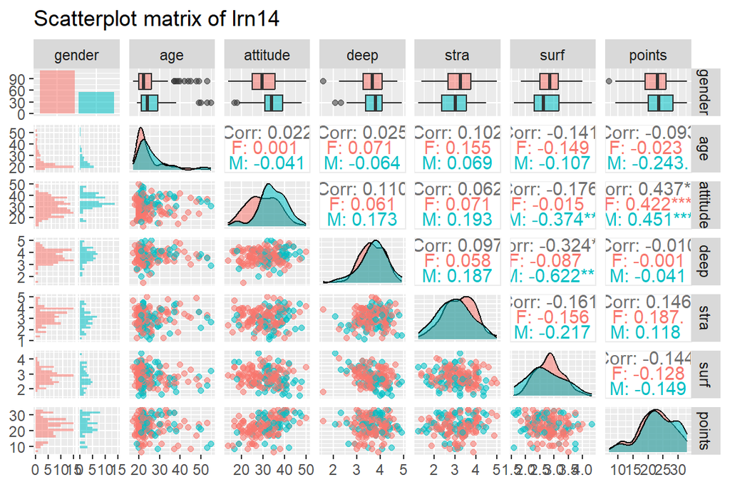

```r
# 2. Show a graphical overview of the data.

library(GGally)
library(ggplot2)

p1 <- ggpairs(lrn14, mapping = aes(col = gender, alpha = 0.4),
              lower = list(combo = wrap("facethist", bins = 20)),
              title = "Scatterplot matrix of lrn14")

p1 #show the graphics
```

- The number of males (blue) is app. half of the number of females (red).
  - The total number of females is 110 and 56 for males (see the code below).
- Most students are around 20 years old and the age distribution is positively (right-) skewed.
- Other variables are quite normally distributed, but “points” is slightly negatively/left skewed in both gender, attitude and deep questions left-skewed, and surf questions slightly right-skewed in males.
- There are some outliers in attitude (males), deep, and points (females). As the age distribution is so wide and skewed, there seem to be statistical (not true) outliers in age.
- There are some statistically significant correlations between (all * are not visible in the matrix as I wasn’t able to fix the font properly, sorry!)
  - Attitude and surf in males (neg.)
  - Attitude and total points overall and separately in both genders (pos.)
  - Deep and surf in males and overall (neg., not separately in females)
  - Stra and Surf overall (neg., not separately in each gender)

```r
# ...and show summaries of the variables in the data.
summary(lrn14)
```

```
##     gender               age           attitude          deep
##  Length:166         Min.   :17.00   Min.   :14.00   Min.   :1.583
##  Class :character   1st Qu.:21.00   1st Qu.:26.00   1st Qu.:3.333
##  Mode  :character   Median :22.00   Median :32.00   Median :3.667
##                     Mean   :25.51   Mean   :31.43   Mean   :3.680
##                     3rd Qu.:27.00   3rd Qu.:37.00   3rd Qu.:4.083
##                     Max.   :55.00   Max.   :50.00   Max.   :4.917
##       stra            surf           points
##  Min.   :1.250   Min.   :1.583   Min.   : 7.00
##  1st Qu.:2.625   1st Qu.:2.417   1st Qu.:19.00
##  Median :3.188   Median :2.833   Median :23.00
##  Mean   :3.121   Mean   :2.787   Mean   :22.72
##  3rd Qu.:3.625   3rd Qu.:3.167   3rd Qu.:27.75
##  Max.   :5.000   Max.   :4.333   Max.   :33.00
```

```r
# see the exact number of males and females
library(tidyverse)
lrn14 %>%
 count(gender)
```

| gender | n |
| --- | --- |
| F | 110 |
| M | 56 |

```r
# 3. Regression model

# 3.1 Linear model with explanatory variables: attitude, stra and surf, output/dependent variable: points

my_model1 <- lm(points ~ attitude + stra + surf, data = lrn14)
summary(my_model1)
```

```
##
## Call:
## lm(formula = points ~ attitude + stra + surf, data = lrn14)
##
## Residuals:
##      Min       1Q   Median       3Q      Max
## -17.1550  -3.4346   0.5156   3.6401  10.8952
##
## Coefficients:
##             Estimate Std. Error t value Pr(>|t|)
## (Intercept) 11.01711    3.68375   2.991  0.00322 **
## attitude     0.33952    0.05741   5.913 1.93e-08 ***
## stra         0.85313    0.54159   1.575  0.11716
## surf        -0.58607    0.80138  -0.731  0.46563
## ---
## Signif. codes:  0 '***' 0.001 '**' 0.01 '*' 0.05 '.' 0.1 ' ' 1
##
## Residual standard error: 5.296 on 162 degrees of freedom
## Multiple R-squared:  0.2074, Adjusted R-squared:  0.1927
## F-statistic: 14.13 on 3 and 162 DF,  p-value: 3.156e-08
```

## Model 1

In this linear regression model the exam points are explained by three variables: attitude, points of Strategic approach and Surface approach.

The intercept refers the value of *y* when *x* = 0. When there are multiple explanatory variable, it is the mean value of response variable when all x = 0. The values below (“Estimate”) means the slopes of the each parallel fitted line for each explanatory variable. Values >0 refers positive relationship and <0 negative relationship. E.g. higher points in attitude increases the predicted amount of points in the exam. The asterisk (*) shows statistically significant (p< 0.05) relationships.

The residual standard error is the standard deviation of the residuals referring the distance between each observation and the fitted line.

Multiple R-squared and Adjusted R-squared are (multiple) correlation coefficients measuring the linear correlation between explanatory and dependent variables. The adjusted R-squared is a modified version of R-squared that adjusts for the number of predictors in a regression model.

R-squared means how much (a proportion) the explanatory variables in this model can explain the variance of the outcome variable, which is here the exam points. R-squared can range from 0 to 1. R-squared 1 means that 100 % of the variance seen in the outcome variable can be explained by the explanatory variables. Thus, in the model1 three explanatory variables explain app. 19 % of the total exam points.

However, in this model1 only attitude significantly correlated to the exam points so stra and surf are not very useful or give any additional value in the model.

Let’s make a new model:

```r
# 3.2 Explanatory variable: attitude (as it was only with a significant relationship)
my_model2 <- lm(points ~ attitude, data = lrn14)
summary(my_model2)
```

```
##
## Call:
## lm(formula = points ~ attitude, data = lrn14)
##
## Residuals:
##      Min       1Q   Median       3Q      Max
## -16.9763  -3.2119   0.4339   4.1534  10.6645
##
## Coefficients:
##             Estimate Std. Error t value Pr(>|t|)
## (Intercept) 11.63715    1.83035   6.358 1.95e-09 ***
## attitude     0.35255    0.05674   6.214 4.12e-09 ***
## ---
## Signif. codes:  0 '***' 0.001 '**' 0.01 '*' 0.05 '.' 0.1 ' ' 1
##
## Residual standard error: 5.32 on 164 degrees of freedom
## Multiple R-squared:  0.1906, Adjusted R-squared:  0.1856
## F-statistic: 38.61 on 1 and 164 DF,  p-value: 4.119e-09
```

## Model 2

As the parameters in the model2 compared to the model 1 are quite similar, we can conclude that in both models attitude is the main explanatory variable predicting the exam points. However, it has only quite a minor role in the outcome (points) and the model is not very useful for prediction. There seems to be unknown variables that mostly effect the success in the exam.

The R-squared values are slightly lower in the models 2. This is due to the fact that adding a new predictor variable to the model the R-squared will increase even if the predictor variable isn’t useful (ref: https://www.statology.org/multiple-r-vs-r-squared/).

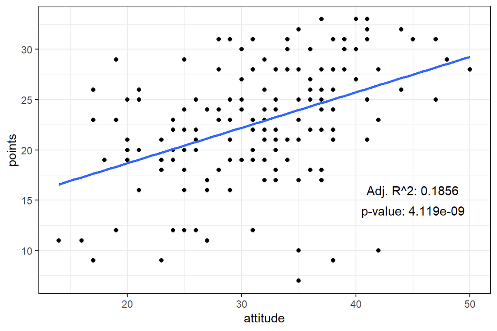

```r
# We can also plot the new model:
library(ggplot2)

p2 <- ggplot(lrn14, aes(attitude, points))+
  geom_point()+
  geom_smooth(method = "lm", se=FALSE)+
  theme_bw()+
  annotate("text", x=45, y=16, label="Adj. R^2: 0.1856")+
  annotate("text", x=45, y=14, label= "p-value: 4.119e-09")

p2
```

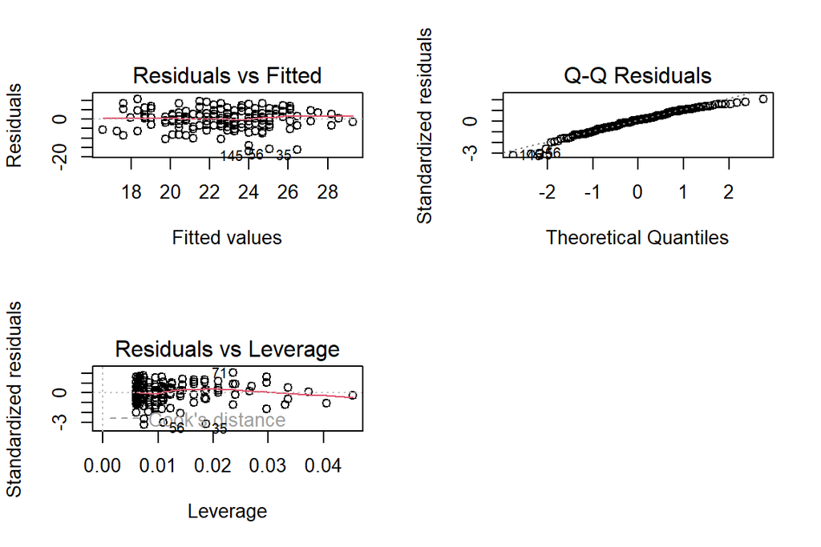

```r
#4 Produce the following diagnostic plots: Residuals vs Fitted values, Normal QQ-plot and Residuals vs Leverage. Explain the assumptions of the model and interpret the validity of those assumptions based on the diagnostic plots

par(mfrow = c(2,2))
plot(my_model2, which = c(1,2,5))
```

## Interpretation of model validity

Linear regression modelling has four main assumptions:

1. Linear relationship between predictors and outcome;
2. Independence of residuals;
3. Normal distribution of residuals;
4. Equal variance of residuals.

*Harrison & Pius, 2021. R for Health Data Science.*

**Residuals vs. Fitted** plot is used to check the assumptions 1-2 and 4:  
A horizontal line closed to 0 is an indicator of a linear relationship and the residuals do not show any fitted pattern. This seems to be fine in the model 2.

**Q-Q Residuals** to check the 3. assumption:  
Residuals are normally distributed when all plots follow approximately the reference line. The model2 shows quite good but not optimal as there are some dispersion at the extreme ends.

**Residuals vs. Leverage** plot can show outliers or those values that have a strong influence in a regression model.  
The model2 does not show clear outlying observations and there are no observations which remarkably exceed the Cook’s distance (= observations with a high influence).

In summary, based on the results presented above it can be concluded that  
- there is a linear and positive relationship between the attitude and the total points in an exam  
- attitude explains app. 19 % of the variance in exam points, and  
- the linear regression model (model2) is (technically) valid but not very useful in predicting exam points based on attitude.

# Logistic regression

This week I felt lacking time to go through everything properly. I was struggling a bit to convert summary tibbles into tidier tables but luckily found one solution for it. There are so much to learn still..

## About the data

```r
setwd("C:/Users/ainopii/Documents/IODS/IODS-project/data/")
library(readr)

# reading the data for analysis
alc <- read_csv("student alc.csv", col_names = TRUE)
#printing column names
colnames(alc)
```

```
##  [1] "school"     "sex"        "age"        "address"    "famsize"
##  [6] "Pstatus"    "Medu"       "Fedu"       "Mjob"       "Fjob"
## [11] "reason"     "guardian"   "traveltime" "studytime"  "schoolsup"
## [16] "famsup"     "activities" "nursery"    "higher"     "internet"
## [21] "romantic"   "famrel"     "freetime"   "goout"      "Dalc"
## [26] "Walc"       "health"     "failures"   "paid"       "absences"
## [31] "G1"         "G2"         "G3"         "alc_use"    "high_use"
```

```r
# dim(alc) #additional to check the total number of rows and columns.
```

Student alc -data contains joined data from two data sets from https://www.archive.ics.uci.edu/dataset/320/student+performance

Data includes 370 observations and 35 variables including demographics, background variables, data on alcohol use, school grades and absences. The average amount of absences and failures at school and average school grades (G1, G2, G3) have been calculated based on the values in two original data sets. Averaged weekly alcohol use (alc_use) has been calculated based on total alcohol consumption during weekdays and weekend. High alcohol use means alc_use > 2 (ranked by 1 - very low to 5 - very high)).

## Exploring the data

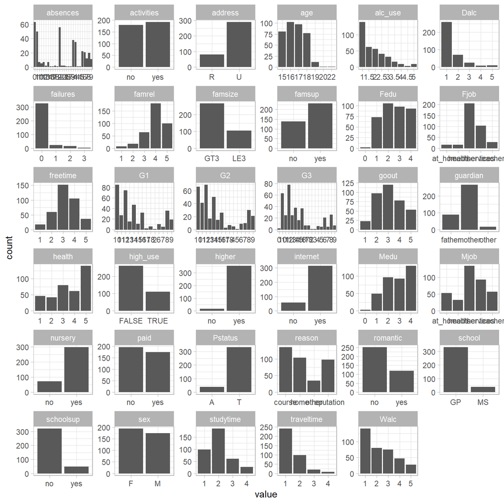

```r
#Visualizing the data with a bar plot of each variable

library(tidyr)
library(dplyr)
library(ggplot2)
theme_set(theme_light()) #changing the default theme for plots

# Using gather() function to create key(=each column/variable)-value(=observations) pairs and then plot each pairs with ggplot().
gather(alc) %>%
  ggplot(aes(value)) + facet_wrap("key", scales = "free") +
  geom_bar()
```

```r
# Exploring the age and sex distributions in more details
alc %>% group_by(sex, high_use) %>%
  summarise(count = n(), mean(age), min(age), max(age), sd(age)) %>%
  mutate(count_sex = sum(count),
         percentage = (count/count_sex))
```

[output not shown]

| sex | high_use | count | mean(age) | min(age) | max(age) | sd(age) | count_sex | percentage |
| --- | --- | --- | --- | --- | --- | --- | --- | --- |
| F | FALSE | 154 | 16.61688 | 15 | 19 | 1.091848 | 195 | 0.7897436 |
| F | TRUE | 41 | 16.48780 | 15 | 19 | 1.120758 | 195 | 0.2102564 |
| M | FALSE | 105 | 16.31429 | 15 | 20 | 1.242781 | 175 | 0.6000000 |
| M | TRUE | 70 | 16.92857 | 15 | 22 | 1.231488 | 175 | 0.4000000 |

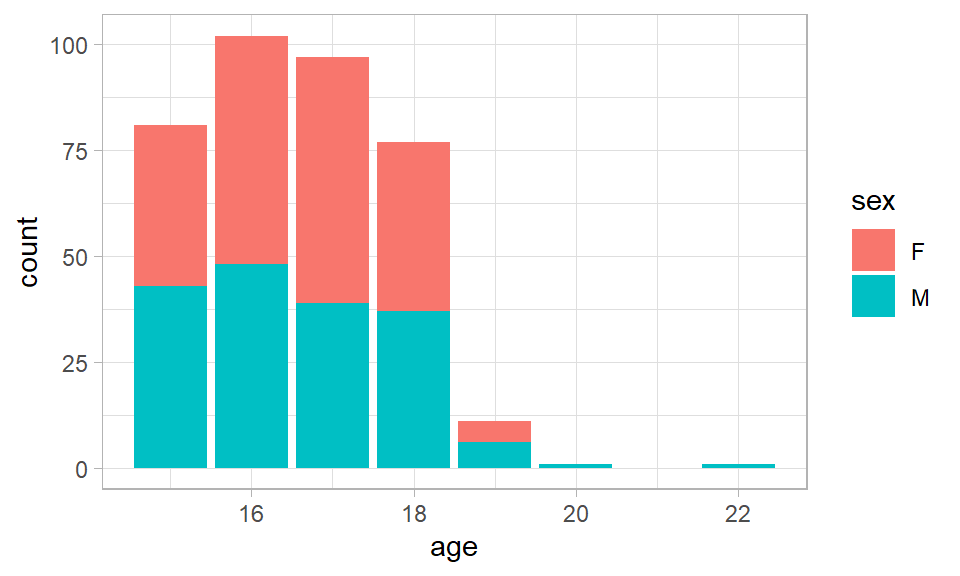

```r
alc %>% ggplot(aes(x=age, fill=sex))+
  geom_bar()
```

As seen in the bar plots, the data consists of school, family, health and free time related data on boys and girls mostly 15-18 years old. There seems to a bit more girls (n=195) than boys (n=175) with the similar age distributions (expect of a couple of older boys).

The overview summary graph shows that there are unequal group sizes in many binomial variables. This should be consider in further analysis as logistic regression models using imbalanced data tend to be biased towards the majority class. Therefore, we might select the binomial variables with more equal group size, e.g. “activities”, “sex”, and “paid”. To note, minority of students belong to the high alcohol use (the outcome variable) -group: 21 % of girls and 40 % of boys.

This analysis **aims** to study relationships between high/low alcohol consumption and **1) sex 2) current health status (health) 3) quality of family relationships (famrel) and 4) final grade (G3)**

I hypothesize that  
1) boys use (slightly) more alcohol than girls  
2) students who feels healthier (higher “health”) may consume less alcohol  
3) students who are using more alcohol (“high_use”=TRUE) have more problems in their family relationships (lower famrel)  
4) students using more alcohol have lower final grades.

```r
# Exploring distribution of high alcohol use, sex, current health and family relationships.
alc %>% group_by(high_use) %>%
  summarise(count = n(), mean(G3), mean(health), mean(famrel)) %>%
  mutate(total = sum(count),
         percentage = (count/total))
```

| high_use | count | mean(G3) | mean(health) | mean(famrel) | total | percentage |
| --- | --- | --- | --- | --- | --- | --- |
| FALSE | 259 | 11.79923 | 3.490347 | 4.007722 | 370 | 0.7 |
| TRUE | 111 | 10.85586 | 3.729730 | 3.765766 | 370 | 0.3 |

```r
# the same with grouping by sex
alc %>% group_by(sex, high_use) %>%
  summarise(count = n(), mean(G3), mean(health), mean(famrel))
```

[output not shown]

| sex | high_use | count | mean(G3) | mean(health) | mean(famrel) |
| --- | --- | --- | --- | --- | --- |
| F | FALSE | 154 | 11.44156 | 3.370130 | 3.922078 |
| F | TRUE | 41 | 11.75610 | 3.390244 | 3.731707 |
| M | FALSE | 105 | 12.32381 | 3.666667 | 4.133333 |
| M | TRUE | 70 | 10.32857 | 3.928571 | 3.785714 |

In general, 30 % of students belongs to the high_use group. The mean final grade the quality of family relationships are a bit lower in the high users groups as expected. Contrary to hypothesis, the current health status seems to be better in the high users -group. This might be affected by confounding factors, such as attitudes (towards drinking) and age-related issues, relationships with friends and freetime activities. Additionally, adolescents may ignore the negative side effects of drinking.

There seems to be differences between boys and girls in most variables, so it is important to consider the sex as an explanatory variable.

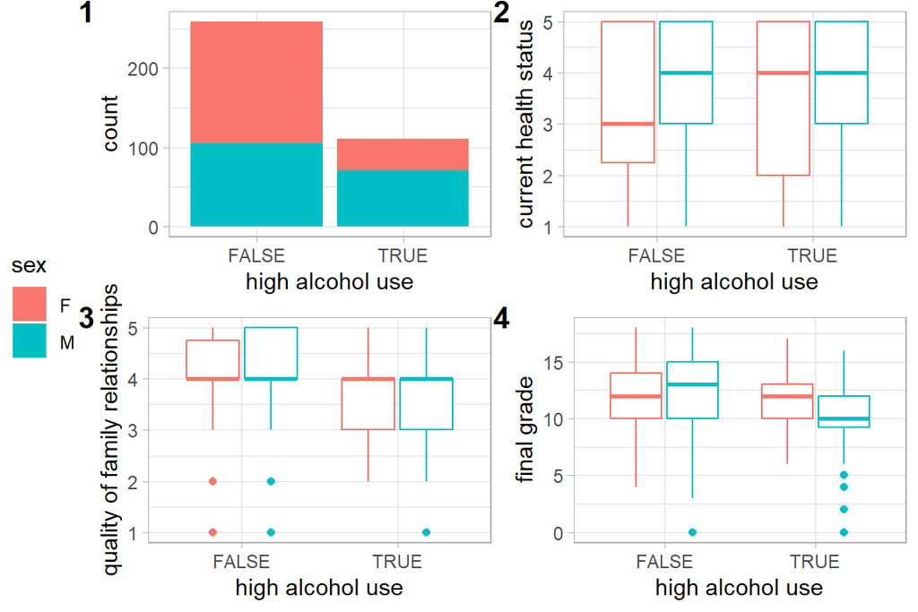

```r
# Exploring relationship of high alcohol use, sex, current health and family relationships.

theme_set(theme_light()) #changing the default theme for plots
library(ggpubr) #to combine all plots into one plot
# create a bar plot of high use and sex
p1 <- alc %>%
  ggplot(aes(x= high_use, fill = sex))+
  geom_bar()+
  xlab("high alcohol use")

# create a box plot of high use and health status, grouped by gender
p2 <- alc %>%
  ggplot(aes(x= high_use, y=health, col= sex))+
  geom_boxplot()+
  xlab("high alcohol use")+
  ylab("current health status")

# create a box plot of high use and quality of family relationships, grouped by gender
p3 <- alc %>%
  ggplot(aes(high_use, y= famrel, col= sex))+
  geom_boxplot()+
  xlab("high alcohol use")+
  ylab("quality of family relationships")

# create a box plot of the high_use and the final grade, grouped by gender
p4 <- alc %>%
  ggplot(aes(x= high_use, y = G3, col= sex))+
  geom_boxplot()+
  ylab("final grade")+
  xlab("high alcohol use")

# combining and adjusting all plots in the same figure using ggarrange() in ggpubr.
ggarrange(p1, p2, p3, p4,
          labels = c("1", "2", "3", "4"),
           ncol = 2, nrow = 2,
          common.legend = TRUE,
          legend = "left",
          vjust = 1, hjust = 0.5)
```

The summary of distributions of the outcome (high_use) and explanatory variables shows that **boys** are more likely to consume more alcohol than girls as expected.

**Final grade** does not notably seem to differ in girls who drink more vs. less alcohol but boys consuming more alcohol have lower final grades (as expected). There are four boys in high user -group with very low grade (considered as outliers in the plot). However, distribution of the final grade is large also in other boys.

There are overall no big differences in the current **health status** based on the alcohol consumption. Boys have reported a slightly better health status compared to girls. Sex differences in health status could be explained by the fact that girls have more mental health problems in adolescence in general. Additionally, the box plot shows that distribution of health status is wider in girls, and girls consuming more alcohol have reported better health status compared to girls using less alcohol. Thus, the overall difference seen in the link between alcohol use and health is origin from the differences seen in girls specifically. To note, the middle line in the box plot refers the median and the box includes 50 % of observations. The summary tibble above includes mean values. Therefore, one could do opposite conclusions of sex differences in health if only look at the summary table.

The quality of **family relationships** seems to be a bit lower in those who drink more alcohol, as expected. There seems to be no sex differences. It can be speculated whether poor family relationships increase the tendency to use more alcohol or vice versa. Probably there are several factors affecting both issues.

```r
# additional way to tabulate data to check relationships between explanatory and outcome variables
library(finalfit)

dependent <- "high_use"
explanatory <- c("sex", "health", "famrel", "G3")
alc %>%
  summary_factorlist(dependent, explanatory, p = TRUE,
                     add_dependent_label = TRUE)
```

| Dependent: high_use |  | FALSE | TRUE | p |
| --- | --- | --- | --- | --- |
| sex | F | 154 (59.5) | 41 (36.9) | <0.001 |
|  | M | 105 (40.5) | 70 (63.1) |  |
| health | Mean (SD) | 3.5 (1.4) | 3.7 (1.4) | 0.134 |
| famrel | Mean (SD) | 4.0 (0.9) | 3.8 (0.9) | 0.019 |
| G3 | Mean (SD) | 11.8 (3.4) | 10.9 (3.0) | 0.011 |

Sex, family relationship and final grade show statistically significant relationship with high alcohol use.

## Logistic regression model

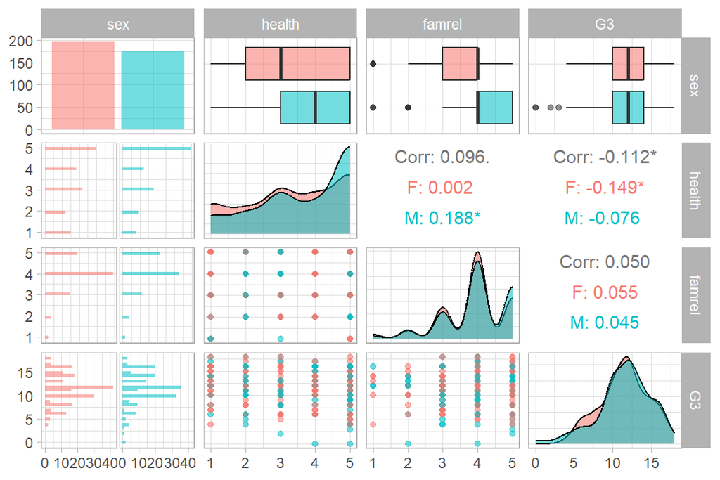

```r
# Extra: checking the assumption of Multicollinearity: explanatory variables should not correlate with each others.
library(GGally)

alc %>%
  remove_labels() %>%  # ggpairs doesn't work well with labels
  ggpairs(columns = explanatory, mapping = aes(col = sex, alpha = 0.4))
```

There are statistically significant correlation between the final grade and health. As health does not show statistically significant relationship with high alcohol use, it could be removed from the analysis. However, let’s not continue with all explanatory variables…

```r
library(tidyverse)

# logistic regression model

m1 <- glm(high_use ~ sex + health + famrel + G3, data = alc, family = "binomial")

# print out a summary of the model
summary(m1)
```

```
##
## Call:
## glm(formula = high_use ~ sex + health + famrel + G3, family = "binomial",
##     data = alc)
##
## Coefficients:
##             Estimate Std. Error z value Pr(>|z|)
## (Intercept)  0.60276    0.70182   0.859  0.39042
## sexM         0.96146    0.24174   3.977 6.97e-05 ***
## health       0.08965    0.08792   1.020  0.30787
## famrel      -0.33662    0.12847  -2.620  0.00879 **
## G3          -0.08491    0.03639  -2.333  0.01962 *
## ---
## Signif. codes:  0 '***' 0.001 '**' 0.01 '*' 0.05 '.' 0.1 ' ' 1
##
## (Dispersion parameter for binomial family taken to be 1)
##
##     Null deviance: 452.04  on 369  degrees of freedom
## Residual deviance: 422.06  on 365  degrees of freedom
## AIC: 432.06
##
## Number of Fisher Scoring iterations: 4
```

```r
# print out the coefficients of the model
coef(m1)
```

```
## (Intercept)        sexM      health      famrel          G3
##  0.60276486  0.96145652  0.08965440 -0.33661821 -0.08491498
```

The model summary shows that sex, family relationship and final grade (G3) but not health status have statistically significant relationships with high alcohol use. Male sex has positive correlation and both family relationship and final grade have negative correlations with higher alcohol consumption. These results are in line with the plotting results. Sex seems to have strongest and also the most significant correlation while the final grade has only a minor effect (|Estimate| i.e. the slope is small).

```r
# compute odds ratios (OR)
OR <- coef(m1) %>% exp

# compute confidence intervals (CI)
CI <- confint(m1)
# print out the odds ratios with their confidence intervals
cbind(OR, CI)
```

```
##                    OR       2.5 %      97.5 %
## (Intercept) 1.8271637 -0.77171869  1.98759217
## sexM        2.6155032  0.49274622  1.44214153
## health      1.0937962 -0.08103054  0.26449411
## famrel      0.7141815 -0.59110838 -0.08555812
## G3          0.9185904 -0.15727983 -0.01418937
```

Odds ratios (OR) above 1 indicates that the event (here high alcohol use) is more likely to occur when sex = Male or continuous predictor increases. So, boys are about 2.6-times likely to be high consumers than girls.

As the odds for Health is close to 1, there is no real association between the health status in general and alcohol consumption.

These results further support the previous results.

```r
# Exploring the predictive performance of the model.

# Statistically significant explanatory variables: sex, famrel, final grade
library(dplyr)

# predict() the probability of high_use
probabilities <- predict(m1, type = "response")

# add the predicted probabilities to 'alc' as a new variable
alc <- mutate(alc, probability = probabilities)

# use the probabilities to make a prediction of high_use
alc <- mutate(alc, prediction = probability > 0.5)

# see the first ten original classes, predicted probabilities, and class predictions
select(alc, famrel, G3, sex, high_use, probability, prediction) %>% head(10)
```

| famrel | G3 | sex | high_use | probability | prediction |
| --- | --- | --- | --- | --- | --- |
| 4 | 8 | F | FALSE | 0.2397475 | FALSE |
| 5 | 8 | F | FALSE | 0.1838193 | FALSE |
| 4 | 11 | F | TRUE | 0.1964219 | FALSE |
| 3 | 14 | F | FALSE | 0.2409227 | FALSE |
| 4 | 12 | F | FALSE | 0.2117489 | FALSE |
| 5 | 14 | M | FALSE | 0.2974632 | FALSE |
| 4 | 12 | M | FALSE | 0.3699881 | FALSE |
| 4 | 10 | F | FALSE | 0.1819482 | FALSE |
| 4 | 18 | M | FALSE | 0.2277488 | FALSE |
| 5 | 14 | M | FALSE | 0.2974632 | FALSE |

```r
# tabulate the target variable versus the predictions
table(high_use = alc$high_use, prediction = alc$prediction)
```

```
##         prediction
## high_use FALSE TRUE
##    FALSE   247   12
##    TRUE    100   11
```

The cross table shows that if a student is not a high user, the predictions is mostly correct, but most high users are predicted inaccurately in non-high users. This is also seen in the plot below.

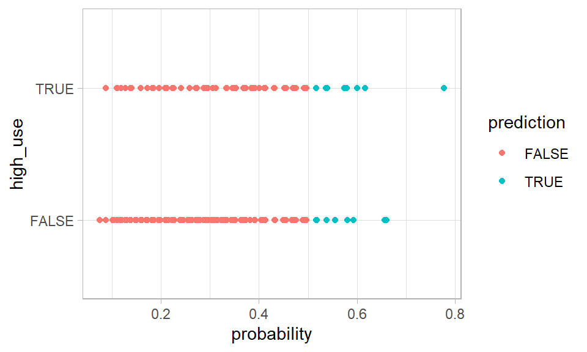

```r
# plotting the true and predicted values for "high use"

plot_m1 <- ggplot(alc, aes(x = probability, y = high_use, col = prediction)) +
  geom_point()

plot_m1
```

```r
# Computing the total proportion of inaccurately classified individuals
# define a loss function (mean prediction error)
loss_func <- function(class, prob) {
  n_wrong <- abs(class - prob) > 0.5
  mean(n_wrong)
}

# call loss_func to compute the average number of wrong predictions in the (training) data
loss_func(class = alc$high_use, prob = alc$probability)
```

```
## [1] 0.3027027
```

As already expected based on the cross-table, the total proportion of inaccurate predictions is quite big: 30 %. Most of students in high use -group have inaccurate prediction but the model can predict quite well and accurately those who are not in the high use group.

All assumptions, for example *linearity of continuous variables to the response*, for logistic regression were not explored and those can affect the model performance. In addition, final grade showed relationship with alcohol consumption only in boys. There might be some interaction between these explanatory variables that decrease the predictive performance of the model.

## Bonus tasks

*Bonus*

```r
# 10-fold cross validation
library(boot)
cv <- cv.glm(data = alc, cost = loss_func, glmfit = m1, K = 10)

# average number of wrong predictions in the cross validation
cv$delta[1]
```

```
## [1] 0.3081081
```

*Super-Bonus*

```r
# Model 2 with more significant predictors

# logistic regression model

m2 <- glm(high_use ~ sex + famrel + failures + absences, data = alc, family = "binomial")

# print out a summary of the model
summary(m2)
```

```
##
## Call:
## glm(formula = high_use ~ sex + famrel + failures + absences,
##     family = "binomial", data = alc)
##
## Coefficients:
##             Estimate Std. Error z value Pr(>|z|)
## (Intercept) -0.79406    0.54281  -1.463  0.14350
## sexM         1.04800    0.25091   4.177 2.96e-05 ***
## famrel      -0.29791    0.13044  -2.284  0.02238 *
## failures     0.57328    0.20531   2.792  0.00523 **
## absences     0.08941    0.02274   3.932 8.43e-05 ***
## ---
## Signif. codes:  0 '***' 0.001 '**' 0.01 '*' 0.05 '.' 0.1 ' ' 1
##
## (Dispersion parameter for binomial family taken to be 1)
##
##     Null deviance: 452.04  on 369  degrees of freedom
## Residual deviance: 401.77  on 365  degrees of freedom
## AIC: 411.77
##
## Number of Fisher Scoring iterations: 4
```

```r
# compute odds ratios (OR)
OR2 <- coef(m2) %>% exp

# compute confidence intervals (CI)
CI2 <- confint(m2)
# print out the odds ratios with their confidence intervals
cbind(OR2, CI2)
```

```
##                   OR2       2.5 %      97.5 %
## (Intercept) 0.4520039 -1.87558320  0.26100198
## sexM        2.8519467  0.56283743  1.54857812
## famrel      0.7423669 -0.55591186 -0.04251048
## failures    1.7740730  0.17701334  0.98884313
## absences    1.0935286  0.04695413  0.13651044
```

```r
# predict() the probability of high_use in model 2
probabilities <- predict(m2, type = "response")

# add the predicted probabilities to 'alc' as a new variable
alc2 <- mutate(alc, probability = probabilities)

# use the probabilities to make a prediction of high_use
alc2 <- mutate(alc, prediction = probability > 0.5)

# tabulate the target variable versus the predictions
table(high_use = alc2$high_use, prediction = alc2$prediction)
```

```
##         prediction
## high_use FALSE TRUE
##    FALSE   247   12
##    TRUE    100   11
```

```r
# 10-fold cross validation
library(boot)
cv2 <- cv.glm(data = alc2, cost = loss_func, glmfit = m1, K = 10)

# average number of wrong predictions in the cross validation
cv2$delta[1]
```

```
## [1] 0.3054054
```

# Clustering and classification

```r
date()
```

```
## [1] "Mon Dec 11 10:13:50 2023"
```

## About the data

```r
# Access the MASS package
library(MASS)
# and load the data
data("Boston")

# exploring the dataset
str(Boston)
```

```
## 'data.frame':    506 obs. of  14 variables:
##  $ crim   : num  0.00632 0.02731 0.02729 0.03237 0.06905 ...
##  $ zn     : num  18 0 0 0 0 0 12.5 12.5 12.5 12.5 ...
##  $ indus  : num  2.31 7.07 7.07 2.18 2.18 2.18 7.87 7.87 7.87 7.87 ...
##  $ chas   : int  0 0 0 0 0 0 0 0 0 0 ...
##  $ nox    : num  0.538 0.469 0.469 0.458 0.458 0.458 0.524 0.524 0.524 0.524 ...
##  $ rm     : num  6.58 6.42 7.18 7 7.15 ...
##  $ age    : num  65.2 78.9 61.1 45.8 54.2 58.7 66.6 96.1 100 85.9 ...
##  $ dis    : num  4.09 4.97 4.97 6.06 6.06 ...
##  $ rad    : int  1 2 2 3 3 3 5 5 5 5 ...
##  $ tax    : num  296 242 242 222 222 222 311 311 311 311 ...
##  $ ptratio: num  15.3 17.8 17.8 18.7 18.7 18.7 15.2 15.2 15.2 15.2 ...
##  $ black  : num  397 397 393 395 397 ...
##  $ lstat  : num  4.98 9.14 4.03 2.94 5.33 ...
##  $ medv   : num  24 21.6 34.7 33.4 36.2 28.7 22.9 27.1 16.5 18.9 ...
```

```r
# more information on the variables
?Boston
```

```
## starting httpd help server ...
```

```
##  done
```

Boston data includes housing data in suburb of Boston. Data consists of 14 numerical variables and 506 observations.  
- **crim**: per capita crime rate by town.  
- **zn**: proportion of residential land zoned for lots over 25,000 sq.ft.  
- **indus**: proportion of non-retail business acres per town.  
- **chas**: Charles River dummy variable (= 1 if tract bounds river; 0 otherwise).  
- **nox**: nitrogen oxides concentration (parts per 10 million).  
- **rm**: average number of rooms per dwelling.  
- **age**: proportion of owner-occupied units built prior to 1940.  
- **dis**: weighted mean of distances to five Boston employment centres.  
- **rad**: index of accessibility to radial highways.  
- **tax**: full-value property-tax rate per $10,000.  
- **ptratio**: pupil-teacher ratio by town.  
- **black**: 1000(Bk - 0.63)^2 where Bk is the proportion of blacks by town.  
- **lstat**: lower status of the population (percent).  
- **medv**: median value of owner-occupied homes in $1000s.

### Graphical overview of the data

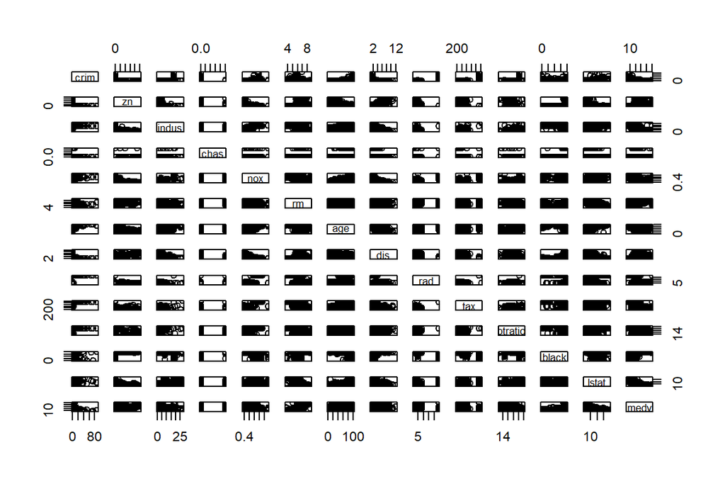

```r
# plot matrix of the variables
p1 <- pairs(Boston)
```

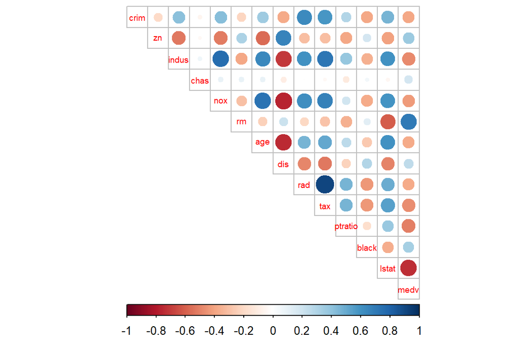

```r
library(tidyr)
library(corrplot)
#correlation plot
# calculate the correlation matrix and round it
cor_matrix <- cor(Boston) %>% round(digits = 2)

# visualize the correlation matrix
p2 <- corrplot(cor_matrix, method="circle", type = "upper", cl.pos = "b", tl.pos = "d", tl.cex = 0.6)
```

```r
# summaries of the variables
summary(Boston)
```

```
##       crim                zn             indus            chas
##  Min.   : 0.00632   Min.   :  0.00   Min.   : 0.46   Min.   :0.00000
##  1st Qu.: 0.08205   1st Qu.:  0.00   1st Qu.: 5.19   1st Qu.:0.00000
##  Median : 0.25651   Median :  0.00   Median : 9.69   Median :0.00000
##  Mean   : 3.61352   Mean   : 11.36   Mean   :11.14   Mean   :0.06917
##  3rd Qu.: 3.67708   3rd Qu.: 12.50   3rd Qu.:18.10   3rd Qu.:0.00000
##  Max.   :88.97620   Max.   :100.00   Max.   :27.74   Max.   :1.00000
##       nox               rm             age              dis
##  Min.   :0.3850   Min.   :3.561   Min.   :  2.90   Min.   : 1.130
##  1st Qu.:0.4490   1st Qu.:5.886   1st Qu.: 45.02   1st Qu.: 2.100
##  Median :0.5380   Median :6.208   Median : 77.50   Median : 3.207
##  Mean   :0.5547   Mean   :6.285   Mean   : 68.57   Mean   : 3.795
##  3rd Qu.:0.6240   3rd Qu.:6.623   3rd Qu.: 94.08   3rd Qu.: 5.188
##  Max.   :0.8710   Max.   :8.780   Max.   :100.00   Max.   :12.127
##       rad              tax           ptratio          black
##  Min.   : 1.000   Min.   :187.0   Min.   :12.60   Min.   :  0.32
##  1st Qu.: 4.000   1st Qu.:279.0   1st Qu.:17.40   1st Qu.:375.38
##  Median : 5.000   Median :330.0   Median :19.05   Median :391.44
##  Mean   : 9.549   Mean   :408.2   Mean   :18.46   Mean   :356.67
##  3rd Qu.:24.000   3rd Qu.:666.0   3rd Qu.:20.20   3rd Qu.:396.23
##  Max.   :24.000   Max.   :711.0   Max.   :22.00   Max.   :396.90
##      lstat            medv
##  Min.   : 1.73   Min.   : 5.00
##  1st Qu.: 6.95   1st Qu.:17.02
##  Median :11.36   Median :21.20
##  Mean   :12.65   Mean   :22.53
##  3rd Qu.:16.95   3rd Qu.:25.00
##  Max.   :37.97   Max.   :50.00
```

The plot matrix includes each pair of variables existing in the data. The plot matrix might not look very clear but it shows some overall distributions and possible relationships between variables. For example, there seem to be two clusters in the pairs including *chas*, *rad* and *tax* variables.

The correlation plot shows the overview of the relationships between different variables. Blue color indicates here positive relationship and red negative relationship. The size of the circle and the intense of the color indicates the strength of the relationship. For example, the plot reveals the strongest positive relationships between *rad* and *tax* and the strongest negative relationships between *age* and *dis*, *lstat* and *medv*, *nox* and *dis*, and *indust* and *dis*. *Chas* variable shows the weakest or no relationship with any other variable.

The summary matrix shows that some variables, like *crim*, *zn*, and *black* seems to be skewed while some variables, like *nox*, *medv*, and *rm* are more normally distributed. Additionally, the values vary largely between variables from 0 to hundreds. So, observations of the variables seems to be in different scales.

## Data processing

### Standardizing the dataset

```r
# still working with
library(MASS)

# Standardizing the dataset
boston_scaled <- scale(Boston)

# summaries of the scaled variables
summary(boston_scaled)
```

```
##       crim                 zn               indus              chas
##  Min.   :-0.419367   Min.   :-0.48724   Min.   :-1.5563   Min.   :-0.2723
##  1st Qu.:-0.410563   1st Qu.:-0.48724   1st Qu.:-0.8668   1st Qu.:-0.2723
##  Median :-0.390280   Median :-0.48724   Median :-0.2109   Median :-0.2723
##  Mean   : 0.000000   Mean   : 0.00000   Mean   : 0.0000   Mean   : 0.0000
##  3rd Qu.: 0.007389   3rd Qu.: 0.04872   3rd Qu.: 1.0150   3rd Qu.:-0.2723
##  Max.   : 9.924110   Max.   : 3.80047   Max.   : 2.4202   Max.   : 3.6648
##       nox                rm               age               dis
##  Min.   :-1.4644   Min.   :-3.8764   Min.   :-2.3331   Min.   :-1.2658
##  1st Qu.:-0.9121   1st Qu.:-0.5681   1st Qu.:-0.8366   1st Qu.:-0.8049
##  Median :-0.1441   Median :-0.1084   Median : 0.3171   Median :-0.2790
##  Mean   : 0.0000   Mean   : 0.0000   Mean   : 0.0000   Mean   : 0.0000
##  3rd Qu.: 0.5981   3rd Qu.: 0.4823   3rd Qu.: 0.9059   3rd Qu.: 0.6617
##  Max.   : 2.7296   Max.   : 3.5515   Max.   : 1.1164   Max.   : 3.9566
##       rad               tax             ptratio            black
##  Min.   :-0.9819   Min.   :-1.3127   Min.   :-2.7047   Min.   :-3.9033
##  1st Qu.:-0.6373   1st Qu.:-0.7668   1st Qu.:-0.4876   1st Qu.: 0.2049
##  Median :-0.5225   Median :-0.4642   Median : 0.2746   Median : 0.3808
##  Mean   : 0.0000   Mean   : 0.0000   Mean   : 0.0000   Mean   : 0.0000
##  3rd Qu.: 1.6596   3rd Qu.: 1.5294   3rd Qu.: 0.8058   3rd Qu.: 0.4332
##  Max.   : 1.6596   Max.   : 1.7964   Max.   : 1.6372   Max.   : 0.4406
##      lstat              medv
##  Min.   :-1.5296   Min.   :-1.9063
##  1st Qu.:-0.7986   1st Qu.:-0.5989
##  Median :-0.1811   Median :-0.1449
##  Mean   : 0.0000   Mean   : 0.0000
##  3rd Qu.: 0.6024   3rd Qu.: 0.2683
##  Max.   : 3.5453   Max.   : 2.9865
```

```r
# checking the class of the boston_scaled object
class(boston_scaled) # "matrix", "array"
```

```
## [1] "matrix" "array"
```

```r
# change the object to data frame
boston_scaled <- as.data.frame(boston_scaled)

# and change scaled crim as numeric
boston_scaled$crim <- as.numeric(boston_scaled$crim)
```

After standardizing the variables, we can see that all variables have now zero as a mean and observations are spreading around the zero. All variables are now in the same scale.

### Categorical variable of the scaled crime rate

```r
# create a quantile vector of crim and print it
bins <- quantile(boston_scaled$crim)
bins
```

```
##           0%          25%          50%          75%         100%
## -0.419366929 -0.410563278 -0.390280295  0.007389247  9.924109610
```

```r
# create a categorical variable 'crime'
crime <- cut(boston_scaled$crim, breaks = bins, include.lowest = TRUE, labels = c("low", "med_low", "med_high", "high"))

# look at the table of the new factor crime
table(crime)
```

```
## crime
##      low  med_low med_high     high
##      127      126      126      127
```

```r
# remove original crim from the dataset
boston_scaled <- dplyr::select(boston_scaled, -crim)

# add the new categorical value to scaled data
boston_scaled <- data.frame(boston_scaled, crime)
```

### Splitting the data to train and test sets

```r
library(dplyr)
library(MASS)

# number of rows in the Boston dataset
n <- nrow(boston_scaled)

# choose randomly 80% of the rows
ind <- sample(n,  size = n * 0.8)

# create train set, including the randomly selecting rows (80 %)
train <- boston_scaled[ind,]

# create test set, including all the remaining 20 % of the rows.
test <- boston_scaled[-ind,]
```

Now we are ready for discriminant analysis…

## Linear discriminant analysis

```r
# linear discriminant analysis
lda.fit <- lda(crime ~ ., data = train)

# print the lda.fit object
lda.fit
```

```
## Call:
## lda(crime ~ ., data = train)
##
## Prior probabilities of groups:
##       low   med_low  med_high      high
## 0.2524752 0.2351485 0.2500000 0.2623762
##
## Group means:
##                   zn      indus        chas        nox         rm        age
## low       0.94620134 -0.9219234 -0.15653200 -0.8597636  0.4718534 -0.8773872
## med_low  -0.07223464 -0.3699272 -0.02367011 -0.5910162 -0.1579548 -0.3586630
## med_high -0.39299539  0.1673922  0.23442641  0.3929373  0.1310366  0.4093636
## high     -0.48724019  1.0149946 -0.01233188  1.0340543 -0.4502069  0.8332588
##                 dis        rad        tax     ptratio       black        lstat
## low       0.8511308 -0.6711095 -0.7501222 -0.49163229  0.38180194 -0.783143374
## med_low   0.3965070 -0.5406181 -0.4950045 -0.05336559  0.31298204 -0.146375124
## med_high -0.3695760 -0.4008151 -0.3157017 -0.34166773  0.09098717 -0.005836262
## high     -0.8794072  1.6596029  1.5294129  0.80577843 -0.75812272  0.939748898
##                 medv
## low       0.55276751
## med_low  -0.03355358
## med_high  0.21087843
## high     -0.71656833
##
## Coefficients of linear discriminants:
##                 LD1         LD2         LD3
## zn       0.12008324  0.62753352 -0.92184348
## indus    0.05453744 -0.28052046  0.17489481
## chas    -0.07002969 -0.05339193  0.14681666
## nox      0.21499435 -0.86891500 -1.28766337
## rm      -0.09424699 -0.12821984 -0.22762448
## age      0.28230171 -0.33840672 -0.01456084
## dis     -0.13022431 -0.29538215  0.17950790
## rad      3.38718677  0.95658476 -0.28503625
## tax      0.04957233  0.04274736  0.67414239
## ptratio  0.13762950 -0.03493486 -0.18607005
## black   -0.14355458  0.05424086  0.11708869
## lstat    0.16542152 -0.24042840  0.28482166
## medv     0.15078949 -0.44959730 -0.23664213
##
## Proportion of trace:
##    LD1    LD2    LD3
## 0.9534 0.0353 0.0113
```

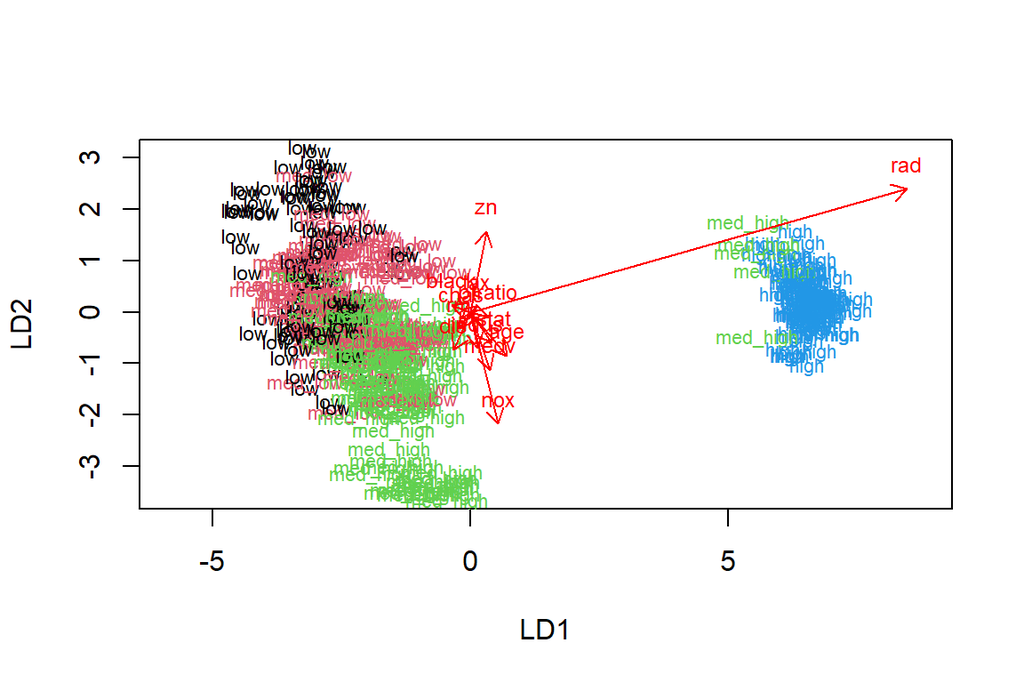

```r
# the function for lda biplot arrows
lda.arrows <- function(x, myscale = 1, arrow_heads = 0.1, color = "red", tex = 0.75, choices = c(1,2)){
  heads <- coef(x)
  graphics::arrows(x0 = 0, y0 = 0,
         x1 = myscale * heads[,choices[1]],
         y1 = myscale * heads[,choices[2]], col=color, length = arrow_heads)
  text(myscale * heads[,choices], labels = row.names(heads),
       cex = tex, col=color, pos=3)
}

# target classes as numeric
classes <- as.numeric(train$crime)

# plot the lda results
plot(lda.fit, dimen = 2, col = classes, pch = classes)
lda.arrows(lda.fit, myscale =2.5)
```

The results of the LDA models shows that there are three linear discriminants in the model: LD1, LD2, and LD3. Each of these are a combination of variables that give the (three) best possible separation between groups. Proportion of trace is the percentage separation achieved by each discriminant function. Thus, the LD1 can separate different groups (or here crime classes) with over 90 % accuracy. To note, the separation percentages for LD2 and LD3 are low (only 1-5 %).

*Rad* shows the strongest (positive) relationship with the crime as the coefficient is around 3 in LD1. Additionally, *nox* and *age* seems to have positive relationship with the target *crim*.

To visually support this, the LDA plot shows the cluster of “high” crime group which is separating from the other classes in LD1 mainly due to the accessibility to radial highways (*rad*). There are also some med_high cases included in this cluster. The other cluster (for LD1) consists of three other groups: low, med_low and most med_high cases. Low group seems to separate from the med_high cases in LD2, mainly due to the *zn* (low), *nox* and *medv* (med_high) variables. Med_low cases seems to be between low and med_high cases.

### LDA prediction

```r
library(MASS)

# save the correct classes from test data
correct_classes <- test$crime

# remove the crime variable from test data
test <- dplyr::select(test, -crime)

# predict classes with test data
lda.pred <- predict(lda.fit, newdata = test)

# cross tabulate the results
table(correct = correct_classes, predicted = lda.pred$class)
```

```
##           predicted
## correct    low med_low med_high high
##   low       14      10        1    0
##   med_low    6      18        7    0
##   med_high   0      10       14    1
##   high       0       0        1   20
```

The cross-tabulation of predicted and correct classed shows that the LDA model is predicting correctly the high class and also quite nicely the low class. For the middle classes there are increasing number of incorrect predictions but still most of the cases are correctly predicted. Thus, the prediction performance of the LDA model is good and excellent for the high class.

### Distance measures

```r
library(MASS)
data("Boston") #reloading the original data

# standardizing the dataset
boston_scaled2 <- scale(Boston)

# calculating Euclidean distances and summarize
dist_eu <- dist(boston_scaled2)
summary(dist_eu)
```

```
##    Min. 1st Qu.  Median    Mean 3rd Qu.    Max.
##  0.1343  3.4625  4.8241  4.9111  6.1863 14.3970
```

### K-means clustering

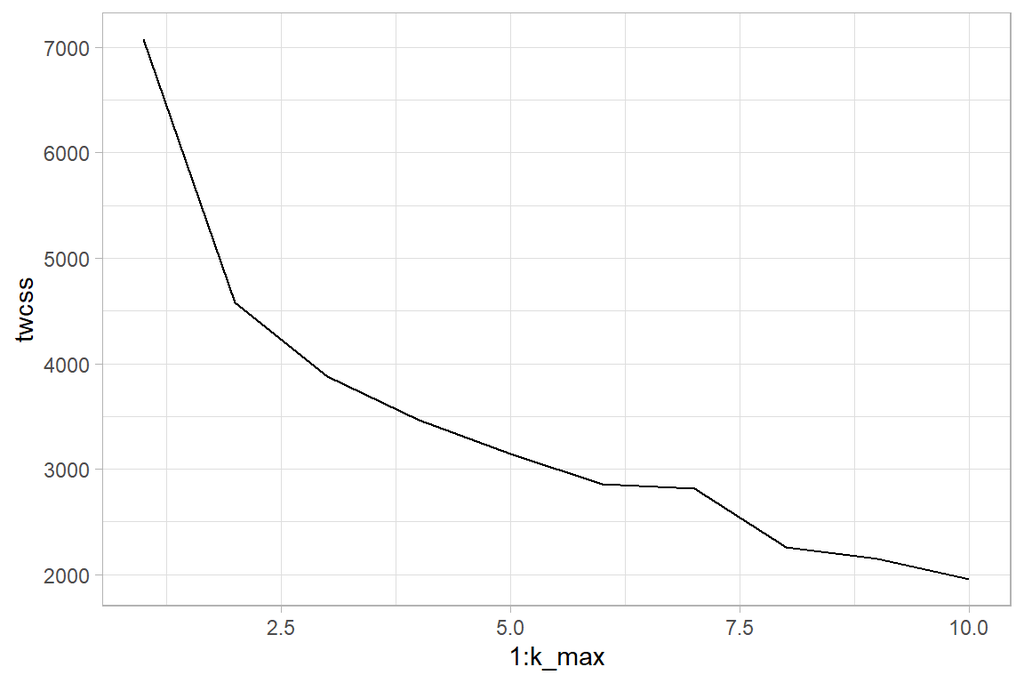

```r
library(MASS)
library(ggplot2)
set.seed(13)

# Run k-means algorithm on the dataset with 4 clusters
km <- kmeans(boston_scaled2, centers = 4)

# investigating the optimal number of clusters. MASS, scaled data already available.
set.seed(123)

# determine the max number of clusters
k_max <- 10

# calculate the total within sum of squares
twcss <- sapply(1:k_max, function(k){kmeans(boston_scaled2, k)$tot.withinss})

# visualize the results
qplot(x = 1:k_max, y = twcss, geom = 'line')
```

The plot above shows that the optimal number of clusters is 2 as the line is dramatically dropping at that point.

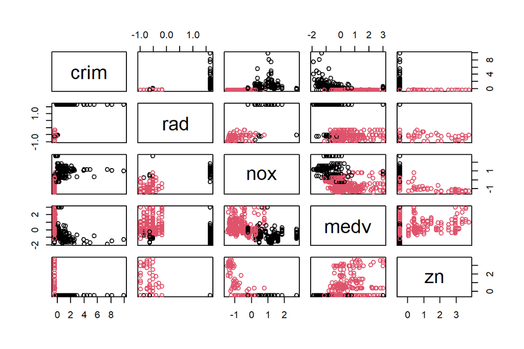

```r
library(MASS)
library(ggplot2)
set.seed(13)

# Run k-means algorithm on the dataset with 2 clusters
km <- kmeans(boston_scaled2, centers = 2)

# plot the Boston dataset with clusters
# pairs(boston_scaled2, col = km$cluster) for overall view, but it's not very clear
# needs to be data frame to plot only some columns, chosen based on the LDA plot.

pairs(as.data.frame(boston_scaled2)[c("crim", "rad", "nox", "medv", "zn")], col = km$cluster)
```

The plot shows that these two clusters are not perfectly separating from each others. Similar was also seen earlier in the LDA plot and in the prediction performance test as there were overlapping in some crime classes. However, we can see clustering in some variable combinations such as *crim* and *rad*, *rad* and *nox* and *crim* and *zn*.

In conclusion, there seems to be some variable combinations but mainly *rad* as a single variable that can accurately separate different crime classes - particularly high and low crime.

# Dimensionality reduction

```r
date()
```

```
## [1] "Mon Dec 11 10:14:02 2023"
```

## About the data

```r
library(readr)

# read data into R from the data folder
human <- read_csv("data/human.csv")
# see the structure and dimensions of the data
str(human)
```

```
## spc_tbl_ [155 × 9] (S3: spec_tbl_df/tbl_df/tbl/data.frame)
##  $ Country  : chr [1:155] "Norway" "Australia" "Switzerland" "Denmark" ...
##  $ Edu2.FM  : num [1:155] 1.007 0.997 0.983 0.989 0.969 ...
##  $ Labo.FM  : num [1:155] 0.891 0.819 0.825 0.884 0.829 ...
##  $ Edu.Exp  : num [1:155] 17.5 20.2 15.8 18.7 17.9 16.5 18.6 16.5 15.9 19.2 ...
##  $ Life.Exp : num [1:155] 81.6 82.4 83 80.2 81.6 80.9 80.9 79.1 82 81.8 ...
##  $ GNI      : num [1:155] 64992 42261 56431 44025 45435 ...
##  $ Mat.Mor  : num [1:155] 4 6 6 5 6 7 9 28 11 8 ...
##  $ Ado.Birth: num [1:155] 7.8 12.1 1.9 5.1 6.2 3.8 8.2 31 14.5 25.3 ...
##  $ Parli.F  : num [1:155] 39.6 30.5 28.5 38 36.9 36.9 19.9 19.4 28.2 31.4 ...
##  - attr(*, "spec")=
##   .. cols(
##   ..   Country = col_character(),
##   ..   Edu2.FM = col_double(),
##   ..   Labo.FM = col_double(),
##   ..   Edu.Exp = col_double(),
##   ..   Life.Exp = col_double(),
##   ..   GNI = col_double(),
##   ..   Mat.Mor = col_double(),
##   ..   Ado.Birth = col_double(),
##   ..   Parli.F = col_double()
##   .. )
##  - attr(*, "problems")=<externalptr>
```

```r
dim(human)
```

```
## [1] 155   9
```

Human data includes numerical values of 8 variables for 155 different countries listed in the first column. There are data about education, working (labor force), life expectancy, Gross National Income (GNI) per Capita, maternal mortality, adolescent births, and proportion of women in parliament.

### Graphical overview of the data

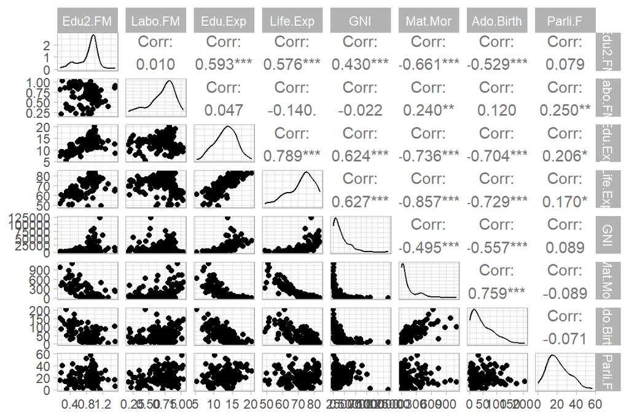

```r
# Moving country names to rownames for visualization
library(tibble)
human2 <- column_to_rownames(human, "Country")

# Access GGally and corrplot for making some overall visualization
library(GGally)
library(corrplot)

# visualize the 'human2' variables
p1 <- ggpairs(human2, progress = FALSE)
p1
```

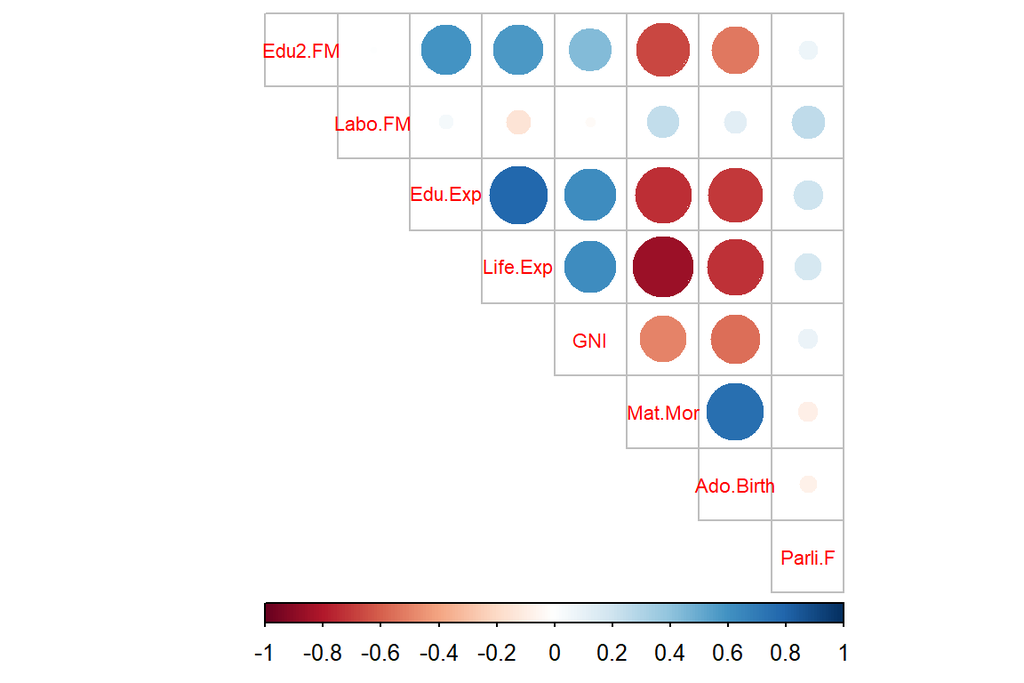

```r
# compute the correlation matrix and visualize it with corrplot
cor(human2) %>%  corrplot(method="circle", type = "upper", cl.pos = "b", tl.pos = "d", tl.cex = 0.7)
```

Plot matrix suggests some linear relationships e.g. - Edu2.FM and Edu.Exp (pos)  
- Edu.Exp and Life.Exp (pos) - more educated people live longer  
- Maternal mortality and Adolescent Birth rate (pos) - countries with more young mothers have more maternal deaths  
- Life.Exp and Mat.Mor (neg) - overall life expectancy is lower if there are higher maternal mortality (very logic as more younger people die)  
- GNI and Edu.Exp (pos) - more educated people indicates slightly the general income level of the country

There are also lots of statistically significant correlations (including all of those listed above). The most strongest correlations are between Mat.Mor and Life.Exp (-0.857), and Life.Ext and Edu.Exp (0.789).

The same findings can be seen in the correlation plot where the size of the circle and intensity of the colour indicates the strength of correlations. Tho correlation plot also shows that the proportions of women in parliament (Parli.F) and the ratio of Labour Force Participation Rates in Females and Males (Labo.FM) do not really correlate with any other variable (just a bit with each others).

```r
# summary of variables
summary(human2)
```

```
##     Edu2.FM          Labo.FM          Edu.Exp         Life.Exp
##  Min.   :0.1717   Min.   :0.1857   Min.   : 5.40   Min.   :49.00
##  1st Qu.:0.7264   1st Qu.:0.5984   1st Qu.:11.25   1st Qu.:66.30
##  Median :0.9375   Median :0.7535   Median :13.50   Median :74.20
##  Mean   :0.8529   Mean   :0.7074   Mean   :13.18   Mean   :71.65
##  3rd Qu.:0.9968   3rd Qu.:0.8535   3rd Qu.:15.20   3rd Qu.:77.25
##  Max.   :1.4967   Max.   :1.0380   Max.   :20.20   Max.   :83.50
##       GNI            Mat.Mor         Ado.Birth         Parli.F
##  Min.   :   581   Min.   :   1.0   Min.   :  0.60   Min.   : 0.00
##  1st Qu.:  4198   1st Qu.:  11.5   1st Qu.: 12.65   1st Qu.:12.40
##  Median : 12040   Median :  49.0   Median : 33.60   Median :19.30
##  Mean   : 17628   Mean   : 149.1   Mean   : 47.16   Mean   :20.91
##  3rd Qu.: 24512   3rd Qu.: 190.0   3rd Qu.: 71.95   3rd Qu.:27.95
##  Max.   :123124   Max.   :1100.0   Max.   :204.80   Max.   :57.50
```

These eight variables have very different ranges e.g., GNI has values from hundreds to hundreds of thousands while two first variables are ratios with values between 0.1-1.5. Thus, data needs to be **scaled** before dimensionality reduction. Otherwise the variables with large values will inappropriately dominate in the analysis.

## Principal component analysis

### PCA with non-scaled variables

```r
# perform principal component analysis (with the SVD method) using non-standardized data, countries are rownames
# as written above, the data needs standardizing but this is just to show what happens if you forget to do it.. :)

pca_human <- prcomp(human2) # precomp() has defaults: retx = TRUE, center = TRUE, scale. = FALSE

# create and print out a summary of pca_human
s1 <- summary(pca_human)
s1
```

```
## Importance of components:
##                              PC1      PC2   PC3   PC4   PC5   PC6    PC7    PC8
## Standard deviation     1.854e+04 185.5219 25.19 11.45 3.766 1.566 0.1912 0.1591
## Proportion of Variance 9.999e-01   0.0001  0.00  0.00 0.000 0.000 0.0000 0.0000
## Cumulative Proportion  9.999e-01   1.0000  1.00  1.00 1.000 1.000 1.0000 1.0000
```

```r
# rounded percentanges of variance captured by each PC
pca_pr <- round(100*s1$importance[2, ], digits = 2)

# print out the percentages of variance
print(pca_pr)
```

```
##   PC1   PC2   PC3   PC4   PC5   PC6   PC7   PC8
## 99.99  0.01  0.00  0.00  0.00  0.00  0.00  0.00
```

[output not shown]

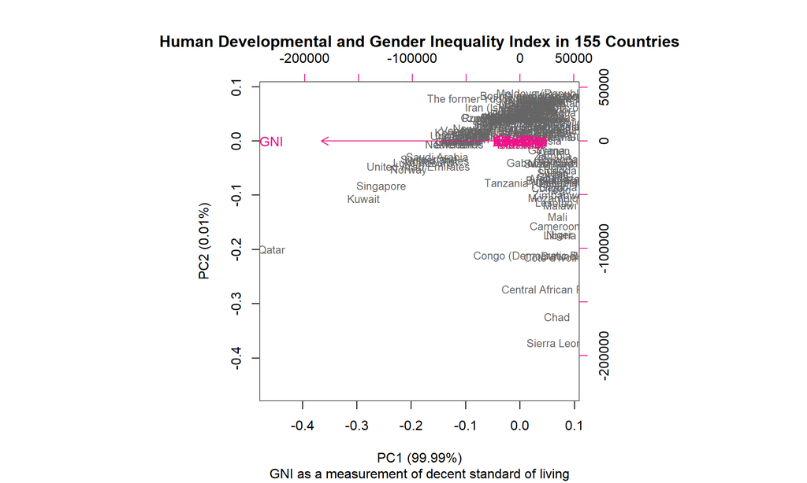

```r
# create object pc_lab to be used as axis labels
pc_lab <- paste0(names(pca_pr), " (", pca_pr, "%)")

# draw a biplot
PCA1 <- biplot(pca_human, cex = c(0.8, 1), col = c("grey40", "deeppink2"),
       xlab = pc_lab[1],
       ylab = pc_lab[2],
       main = "Human Developmental and Gender Inequality Index in 155 Countries",
       sub = "GNI as a measurement of decent standard of living")
```

This does not look good at all. There are also warnings that 5 arrows (for 5 variables) could not be drawn. Here we see that GNI seems to be the (only) variable that distinguish the countries from each others. However, as I used non-standardized data this is a bias occurred due to the larger values of GNI compared to other variables as mentioned earlier. The first principal component (in the x-axis) seems to capture all the variation in the data.

### PCA with scaled variables

```r
# library(ggplot2)

# we need to stardardize the data
human_std <- scale(human2)
summary(human_std)
```

```
##     Edu2.FM           Labo.FM           Edu.Exp           Life.Exp
##  Min.   :-2.8189   Min.   :-2.6247   Min.   :-2.7378   Min.   :-2.7188
##  1st Qu.:-0.5233   1st Qu.:-0.5484   1st Qu.:-0.6782   1st Qu.:-0.6425
##  Median : 0.3503   Median : 0.2316   Median : 0.1140   Median : 0.3056
##  Mean   : 0.0000   Mean   : 0.0000   Mean   : 0.0000   Mean   : 0.0000
##  3rd Qu.: 0.5958   3rd Qu.: 0.7350   3rd Qu.: 0.7126   3rd Qu.: 0.6717
##  Max.   : 2.6646   Max.   : 1.6632   Max.   : 2.4730   Max.   : 1.4218
##       GNI             Mat.Mor          Ado.Birth          Parli.F
##  Min.   :-0.9193   Min.   :-0.6992   Min.   :-1.1325   Min.   :-1.8203
##  1st Qu.:-0.7243   1st Qu.:-0.6496   1st Qu.:-0.8394   1st Qu.:-0.7409
##  Median :-0.3013   Median :-0.4726   Median :-0.3298   Median :-0.1403
##  Mean   : 0.0000   Mean   : 0.0000   Mean   : 0.0000   Mean   : 0.0000
##  3rd Qu.: 0.3712   3rd Qu.: 0.1932   3rd Qu.: 0.6030   3rd Qu.: 0.6127
##  Max.   : 5.6890   Max.   : 4.4899   Max.   : 3.8344   Max.   : 3.1850
```

```r
# perform principal component analysis (with the SVD method) using standardized data, countries are rownames
pca_human_std <- prcomp(human_std)

# create and print out a summary of pca_human
s2 <- summary(pca_human_std)
s2
```

```
## Importance of components:
##                           PC1    PC2     PC3     PC4     PC5     PC6     PC7
## Standard deviation     2.0708 1.1397 0.87505 0.77886 0.66196 0.53631 0.45900
## Proportion of Variance 0.5361 0.1624 0.09571 0.07583 0.05477 0.03595 0.02634
## Cumulative Proportion  0.5361 0.6984 0.79413 0.86996 0.92473 0.96069 0.98702
##                            PC8
## Standard deviation     0.32224
## Proportion of Variance 0.01298
## Cumulative Proportion  1.00000
```

```r
# rounded percentanges of variance captured by each PC
pca_pr2 <- round(100*s2$importance[2, ], digits = 1)

# print out the percentages of variance
print(pca_pr2)
```

```
##  PC1  PC2  PC3  PC4  PC5  PC6  PC7  PC8
## 53.6 16.2  9.6  7.6  5.5  3.6  2.6  1.3
```

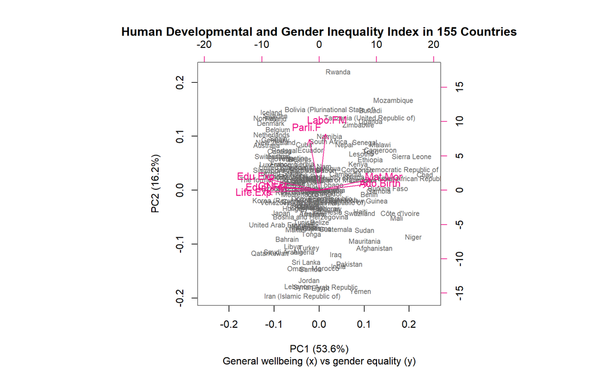

```r
# create object pc_lab to be used as axis labels
pc_lab2 <- paste0(names(pca_pr2), " (", pca_pr2, "%)")

# draw a biplot

PCA2 <- biplot(pca_human_std, cex = c(0.7, 1), col = c("grey40", "deeppink2"), xlab = pc_lab2[1], ylab = pc_lab2[2],
       main = "Human Developmental and Gender Inequality Index in 155 Countries",
       xlim = c(-0.25, 0.25),
       sub = "General wellbeing (x) vs gender equality (y)",
       expand = 1.1)
```

This PCA makes more sense. Now we can see that PC1 explains 53.6 % and PC2 16.2 % of the variation between countries. PC1 seems to include two groups of variables that explains this separation: Maternal mortality and adolescent birth rate at the other end and GNI, Life expectancy, and educational measures at another end. The ratio of Labour Force Participation Rates and the proportions of women in parliament seems to be distinguishing features of PC2. These findings are in line with the previous correlation results (as expected).

Maternal mortality ratio and adolescent birth rate are covered by the **female reproductive health** dimension in Gender Inequality index (GII).  
The variables in the left side of the plot are all part of the **Human Developmental Index** covering all its dimensions. Rest two variables at the top of the plot refers **empowerment** and **gender equality** (higher the values in these the more equal conditions between genders)

Based on this principal component analysis it can be suggested that the countries on the right-hand side in the plot represent poorer and developing countries with worse female reproductive health, shorter life expectancy and worse general education level (and also less educated girls) in population. In contrary, the left-hand side countries include wealthier countries with higher well-being and education. In addition, the lower part of the plot represents countries that have higher gender inequality, meaning that women have worse position in society while the upper part of the plot (see the 0 level in the axis) have more equal situation between genders.

Thus, the PCA plot can be divided into four parts based on the 0-levels in the axis. For example, on the top left there are more wellbeing Scandinavian countries with higher gender equality, women are equally working and taking part of politics. In the contrary, at the bottom right there are countries like Niger, Mauritania and Afganistan where the role of women in society is different and they might be expected to be more at home with children and also women become mothers at earlier age.

## Multiple Correspondence Analysis (MCA)

```r
library(FactoMineR)
```

```r
library(dplyr)
library(tidyr)
library(ggplot2)

tea <- read.csv("https://raw.githubusercontent.com/KimmoVehkalahti/Helsinki-Open-Data-Science/master/datasets/tea.csv", stringsAsFactors = TRUE)

View(tea)
dim(tea)
```

```
## [1] 300  36
```

```r
# summary(tea)
```

Tea data has 300 observations (individuals) and 36 variables. *The tea data comes from the FactoMineR package and it is measured with a questionnaire on tea consumption habits.*

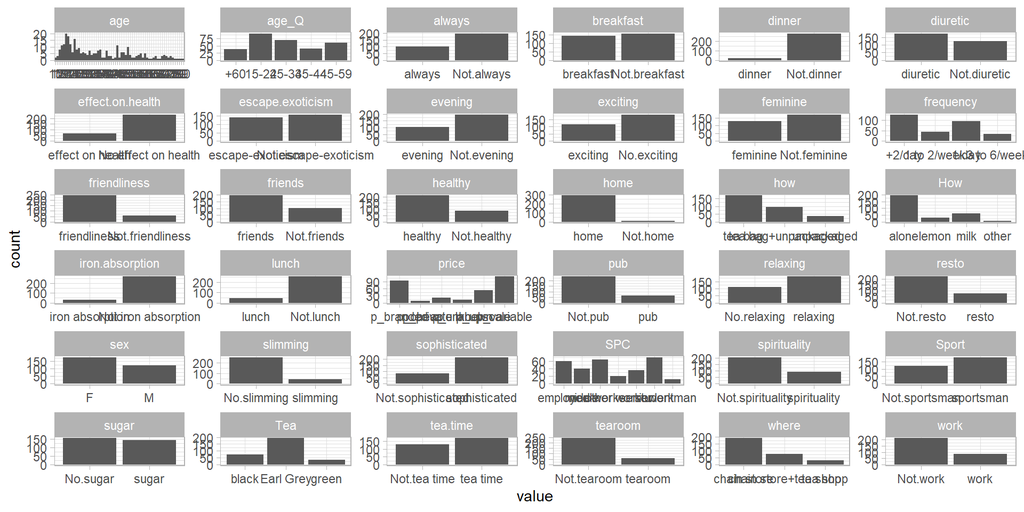

```r
# Visualizing the data

gather(tea) %>%
  ggplot(aes(value)) + facet_wrap("key", scales = "free") +
  geom_bar()
```

The overview plot matrix shows that people of all ages drink tea but most tea drinkers in this data are 15-24 years old and there are more female tea drinkers. People drink tea mostly at home and/or with friends. Earl Grey seems to be most common tea to drink and most people drink it as such (or with sugar).

```r
# Visualizing some of the data in a different way, but first:
# column names to keep in the dataset
keep_columns <- c("Tea", "friends", "age_Q", "How", "how", "sugar", "where", "breakfast")

# select the 'keep_columns' to create a new dataset
tea_time <- dplyr::select(tea, one_of(keep_columns))

# look at the summaries and structure of the data
summary(tea_time)
```

```
##         Tea             friends      age_Q       How
##  black    : 74   friends    :196   +60  :38   alone:195
##  Earl Grey:193   Not.friends:104   15-24:92   lemon: 33
##  green    : 33                     25-34:69   milk : 63
##                                    35-44:40   other:  9
##                                    45-59:61
##                  how           sugar                      where
##  tea bag           :170   No.sugar:155   chain store         :192
##  tea bag+unpackaged: 94   sugar   :145   chain store+tea shop: 78
##  unpackaged        : 36                  tea shop            : 30
##
##
##          breakfast
##  breakfast    :144
##  Not.breakfast:156
##
##
##
```

```r
str(tea_time)
```

```
## 'data.frame':    300 obs. of  8 variables:
##  $ Tea      : Factor w/ 3 levels "black","Earl Grey",..: 1 1 2 2 2 2 2 1 2 1 ...
##  $ friends  : Factor w/ 2 levels "friends","Not.friends": 2 2 1 2 2 2 1 2 2 2 ...
##  $ age_Q    : Factor w/ 5 levels "+60","15-24",..: 4 5 5 2 5 2 4 4 4 4 ...
##  $ How      : Factor w/ 4 levels "alone","lemon",..: 1 3 1 1 1 1 1 3 3 1 ...
##  $ how      : Factor w/ 3 levels "tea bag","tea bag+unpackaged",..: 1 1 1 1 1 1 1 1 2 2 ...
##  $ sugar    : Factor w/ 2 levels "No.sugar","sugar": 2 1 1 2 1 1 1 1 1 1 ...
##  $ where    : Factor w/ 3 levels "chain store",..: 1 1 1 1 1 1 1 1 2 2 ...
##  $ breakfast: Factor w/ 2 levels "breakfast","Not.breakfast": 1 1 2 2 1 2 1 2 1 1 ...
```

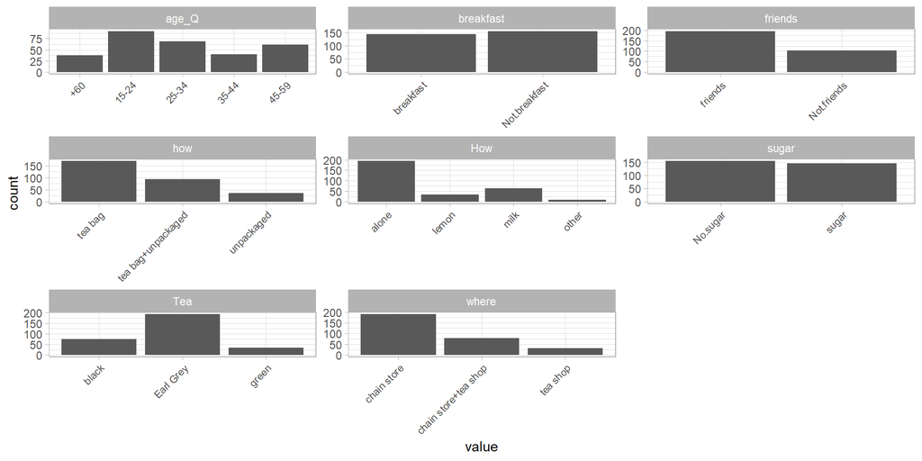

```r
# visualize the dataset
library(ggplot2)
pivot_longer(tea_time, cols = everything()) %>%
  ggplot(aes(value)) + facet_wrap("name", scales = "free")+
  geom_bar()+
  theme(axis.text.x = element_text(angle = 45, hjust = 1, size = 8))
```

A bit clearer figure on the variables to be used in the analysis. We can also see that tea bags are most common to be used and most people but tea from chain stores.

```r
# multiple correspondence analysis
library(FactoMineR)
mca <- MCA(tea_time)
```

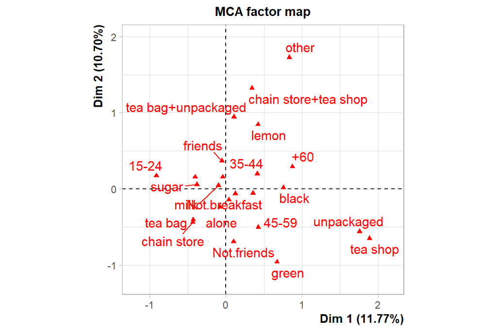

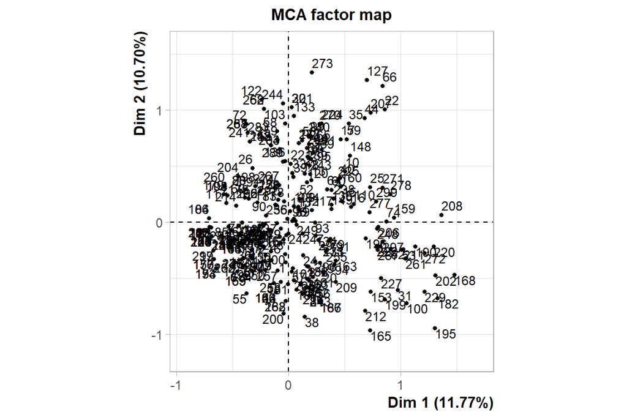

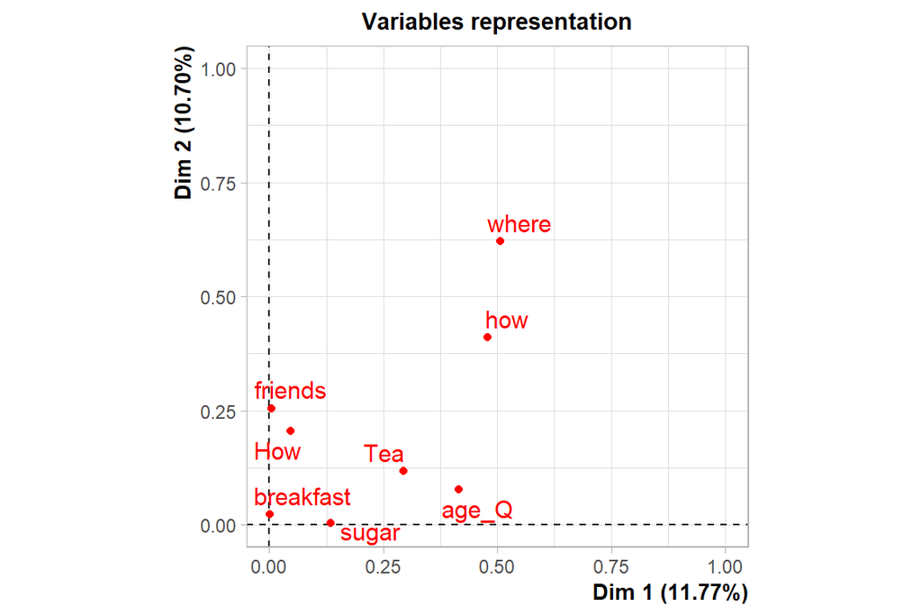

```r
# summary of the model
summary(mca)
```

```
##
## Call:
## MCA(X = tea_time)
##
##
## Eigenvalues
##                        Dim.1   Dim.2   Dim.3   Dim.4   Dim.5   Dim.6   Dim.7
## Variance               0.235   0.214   0.199   0.155   0.149   0.137   0.131
## % of var.             11.769  10.696   9.951   7.761   7.467   6.827   6.525
## Cumulative % of var.  11.769  22.464  32.415  40.176  47.643  54.470  60.995
##                        Dim.8   Dim.9  Dim.10  Dim.11  Dim.12  Dim.13  Dim.14
## Variance               0.117   0.107   0.106   0.099   0.095   0.089   0.072
## % of var.              5.845   5.352   5.321   4.932   4.728   4.432   3.606
## Cumulative % of var.  66.840  72.193  77.514  82.446  87.174  91.606  95.211
##                       Dim.15  Dim.16
## Variance               0.054   0.042
## % of var.              2.688   2.101
## Cumulative % of var.  97.899 100.000
##
## Individuals (the 10 first)
##                Dim.1    ctr   cos2    Dim.2    ctr   cos2    Dim.3    ctr
## 1           | -0.025  0.001  0.000 | -0.362  0.204  0.068 |  0.535  0.479
## 2           |  0.162  0.037  0.013 | -0.506  0.398  0.128 |  1.018  1.736
## 3           | -0.150  0.032  0.021 | -0.339  0.179  0.105 |  0.117  0.023
## 4           | -0.644  0.588  0.388 | -0.413  0.265  0.159 | -0.155  0.040
## 5           | -0.131  0.024  0.013 | -0.544  0.462  0.231 |  0.463  0.359
## 6           | -0.455  0.293  0.197 | -0.443  0.306  0.186 |  0.062  0.006
## 7           | -0.173  0.043  0.021 | -0.068  0.007  0.003 |  0.260  0.113
## 8           |  0.180  0.046  0.014 | -0.397  0.246  0.069 |  0.809  1.096
## 9           |  0.199  0.056  0.016 |  0.562  0.493  0.128 |  0.566  0.537
## 10          |  0.503  0.358  0.106 |  0.449  0.314  0.085 |  0.655  0.719
##               cos2
## 1            0.148 |
## 2            0.519 |
## 3            0.013 |
## 4            0.022 |
## 5            0.167 |
## 6            0.004 |
## 7            0.047 |
## 8            0.285 |
```

[output cut: 22 more lines]

```
## 15-24       |  -0.214   0.882   0.020  -2.461 |
## 25-34       |  -0.851  10.473   0.217  -8.046 |
## 35-44       |   0.472   1.862   0.034   3.198 |
## 45-59       |   0.590   4.448   0.089   5.156 |
##
## Categorical variables (eta2)
##               Dim.1 Dim.2 Dim.3
## Tea         | 0.295 0.117 0.250 |
## friends     | 0.005 0.254 0.083 |
## age_Q       | 0.415 0.078 0.330 |
## How         | 0.046 0.206 0.331 |
## how         | 0.478 0.410 0.144 |
## sugar       | 0.135 0.003 0.149 |
## where       | 0.507 0.621 0.206 |
## breakfast   | 0.002 0.022 0.098 |
```

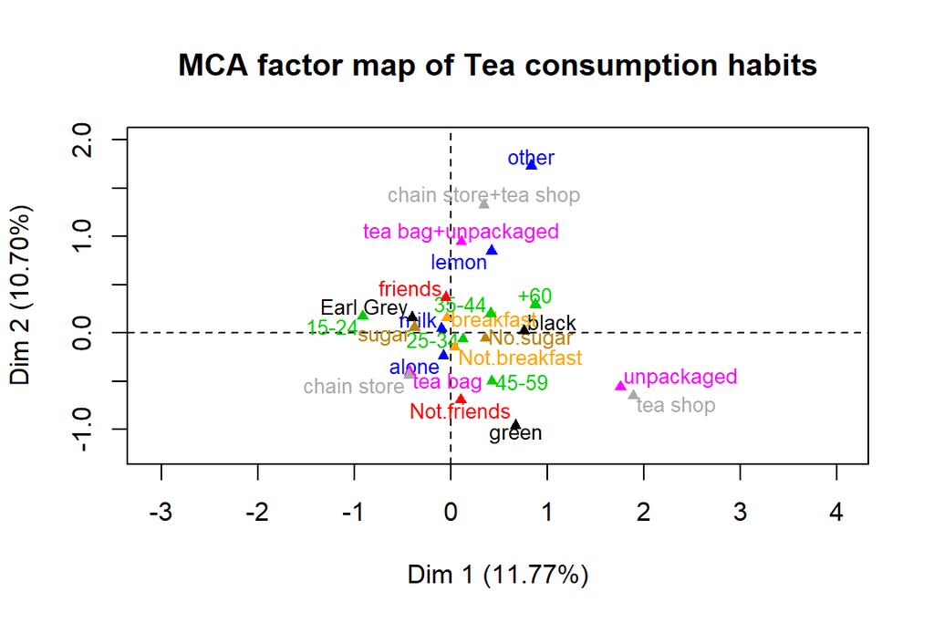

```r
# to check more detailed description on the dimensions of the MCA, not shown here as there are lots of data/numbers
# dimdesc(mca)

# visualize MCA
MCA1 <- plot(mca, invisible = c("ind"), cex = 0.8, graph.type = "classic", habillage= "quali", title = "MCA factor map of Tea consumption habits")
```

The first two dimensions explain both around 10 % of variance. There are no particular groups of individuals as the plots with individuals (black dots) are quite homogeneous. In the **Variables representation** plot we can see that questions about “where to buy tea” and “how the tea is packed” seems to explain most of the variance. It seems that older people (+45 yo.) prefer unpacked (green or black) tea which is bought from a specific tea shop. Younger people seems to prefer Earl Grey tea. In general, no strong conclusions can be made based on these plots.

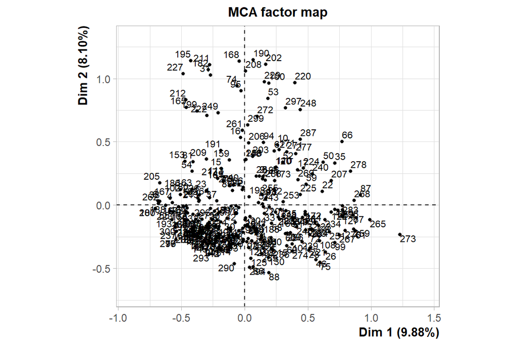

```r
# more plots for the complete data:
# defining columns 19-36 as supplementary data, the rest are "active variables" measuring tea consumption behaviour
mca_all = MCA(tea, quanti.sup=19, quali.sup=c(20:36), graph = FALSE)
plot.MCA(mca_all, invisible=c("var","quali.sup"), cex=0.7)
```

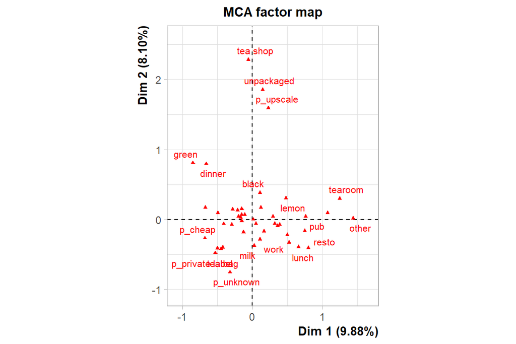

```r
plot.MCA(mca_all, invisible=c("ind","quali.sup"), cex=0.7)
```

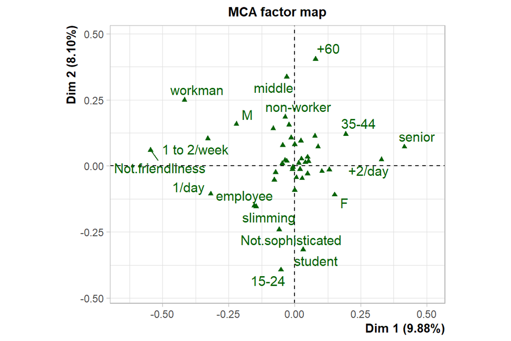

```r
plot.MCA(mca_all, invisible=c("ind", "var"))
```

Using the all data we can still conclude that there are no groups of people in the data. The percentages of first two dimensions are a bit smaller which makes sense as there are more variables included. Tea shop and unpacked tea seems to be still the most effecting variables among the third prizing variable: up-scaled luxury tea. It can be assumed that this kind of fancy tea are most often sold and bought in a tea shop instead of a normal grocery market. The last plot includes the supplementary variable which include characteristics of individuals. The plot suggest that younger (mainly students) and older people have some differences in their tea consumption habits.

# Analysis of longitudinal data

## PART1: *RATS* - a nutritional intervention study

*“The data is from a nutrition study conducted in three groups of rats. The groups were put on different diets, and each animal’s body weight (in grams) was recorded repeatedly (approximately) weekly, except in week seven when two recordings were taken) over a 9-week period. The question of most interest is whether the growth profiles of the three groups differ.”*

```r
# Read the data
library(readr)
RATS <- read_csv("data/rats.tidy.csv")
#check the data
library(tidyverse)
library(modelsummary)
# glimpse(RATS)

# change ID and Group as factors

RATS <- RATS %>%
  mutate(Group = factor(Group),
         ID = factor(ID))

# look at the data
glimpse(RATS)
```

```
## Rows: 176
## Columns: 5
## $ ID     <fct> 1, 2, 3, 4, 5, 6, 7, 8, 9, 10, 11, 12, 13, 14, 15, 16, 1, 2, 3,…
## $ Group  <fct> 1, 1, 1, 1, 1, 1, 1, 1, 2, 2, 2, 2, 3, 3, 3, 3, 1, 1, 1, 1, 1, …
## $ WD     <chr> "WD1", "WD1", "WD1", "WD1", "WD1", "WD1", "WD1", "WD1", "WD1", …
## $ Weight <dbl> 240, 225, 245, 260, 255, 260, 275, 245, 410, 405, 445, 555, 470…
## $ Time   <dbl> 1, 1, 1, 1, 1, 1, 1, 1, 1, 1, 1, 1, 1, 1, 1, 1, 8, 8, 8, 8, 8, …
```

```r
# Print out summaries of the data and variables
datasummary_skim(RATS)
```

|  | Unique (#) | Missing (%) | Mean | SD | Min | Median | Max |  |
| --- | --- | --- | --- | --- | --- | --- | --- | --- |
| Weight | 100 | 0 | 384.5 | 127.2 | 225.0 | 344.5 | 628.0 |  |
| Time | 11 | 0 | 33.5 | 19.5 | 1.0 | 36.0 | 64.0 |  |

```r
summary(RATS)
```

```
##        ID      Group       WD                Weight           Time
##  1      : 11   1:88   Length:176         Min.   :225.0   Min.   : 1.00
##  2      : 11   2:44   Class :character   1st Qu.:267.0   1st Qu.:15.00
##  3      : 11   3:44   Mode  :character   Median :344.5   Median :36.00
##  4      : 11                             Mean   :384.5   Mean   :33.55
##  5      : 11                             3rd Qu.:511.2   3rd Qu.:50.00
##  6      : 11                             Max.   :628.0   Max.   :64.00
##  (Other):110
```

```r
# Summary of mean weight in each group
RATS %>% group_by(Group) %>%
  summarise(mean(Weight))
```

| Group | mean(Weight) |
| --- | --- |
| 1 | 263.7159 |
| 2 | 484.7045 |
| 3 | 525.7955 |

The RATS data has 176 observations and 5 columns. We will use all variables but *WD* which comes from the original wide format data. New variable *Time* was added which is a numeral value subtracted from *WD* meaning the time point (in days) in the intervention. In the group 1 there are 8 rats and both group 2 and 3 have 4 rats in each. The mean weight of each group seems to differ remarkably.

### Individuals on the plot

First, lets check the data without further processing..

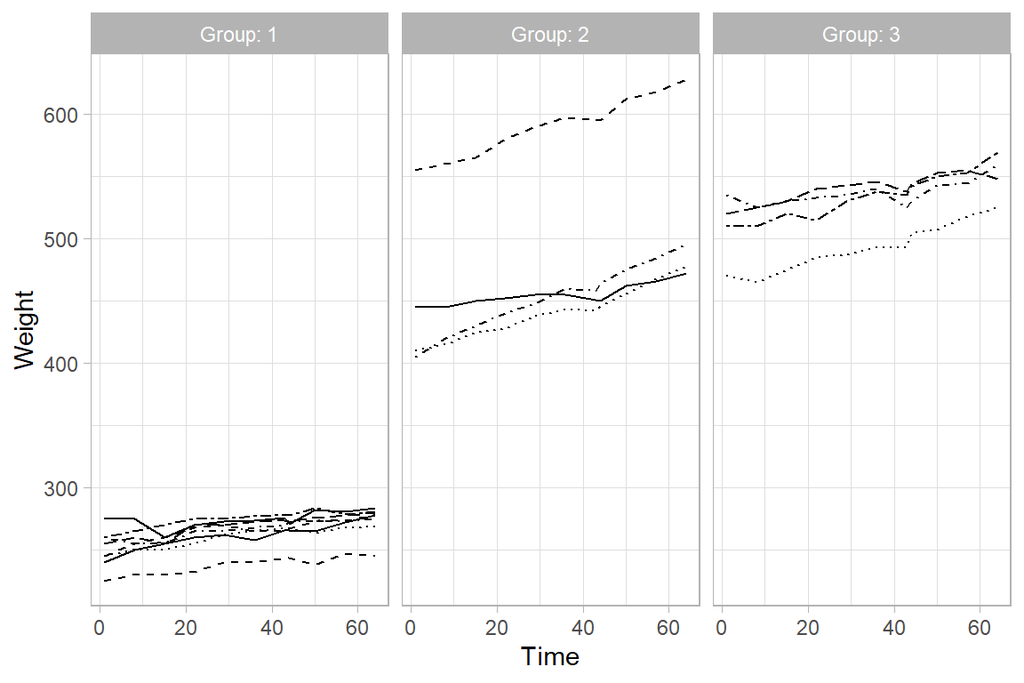

```r
#Access the package ggplot2
library(ggplot2)

# Draw the plot
ggplot(RATS, aes(x = Time, y = Weight, linetype = ID)) +
  geom_line() +
  scale_linetype_manual(values = rep(1:10, times=4)) +
  facet_grid(. ~ Group, labeller = label_both) +
  theme(legend.position = "none") +
  scale_y_continuous(limits = c(min(RATS$Weight), max(RATS$Weight)))
```

In the first plot we can see that the rats in group 1 are lighter in general as seen already in the summary table. It seems that there are increase in weight in all groups but it is more clear in groups 2 and 3. In the group 2 there is one rat that shows overall higher weight compared to the other rats in the group.

Thus, we need to take notice the tracking phenomenon which means the effect of different baseline values on the later values throughout the study. So here, the rats with higher weight at the beginning tend to weight more also at the end. We can visualize this phenomenon by using standardized values of each observation in a plot. For each observation (x) we need to calculate:
$$standardised(x) =
\frac{x - mean(x)}{ sd(x)}$$

#### Standardized data

```r
library(dplyr)
library(tidyr)

# Standardize the variable Weight
RATS <- RATS %>%
  group_by(Time) %>%
  mutate(stdweight = (Weight - mean(Weight))/sd(Weight)) %>%
  ungroup()

# Glimpse the data
glimpse(RATS)
```

```
## Rows: 176
## Columns: 6
## $ ID        <fct> 1, 2, 3, 4, 5, 6, 7, 8, 9, 10, 11, 12, 13, 14, 15, 16, 1, 2,…
## $ Group     <fct> 1, 1, 1, 1, 1, 1, 1, 1, 2, 2, 2, 2, 3, 3, 3, 3, 1, 1, 1, 1, …
## $ WD        <chr> "WD1", "WD1", "WD1", "WD1", "WD1", "WD1", "WD1", "WD1", "WD1…
## $ Weight    <dbl> 240, 225, 245, 260, 255, 260, 275, 245, 410, 405, 445, 555, …
## $ Time      <dbl> 1, 1, 1, 1, 1, 1, 1, 1, 1, 1, 1, 1, 1, 1, 1, 1, 8, 8, 8, 8, …
## $ stdweight <dbl> -1.0011429, -1.1203857, -0.9613953, -0.8421525, -0.8819001, …
```

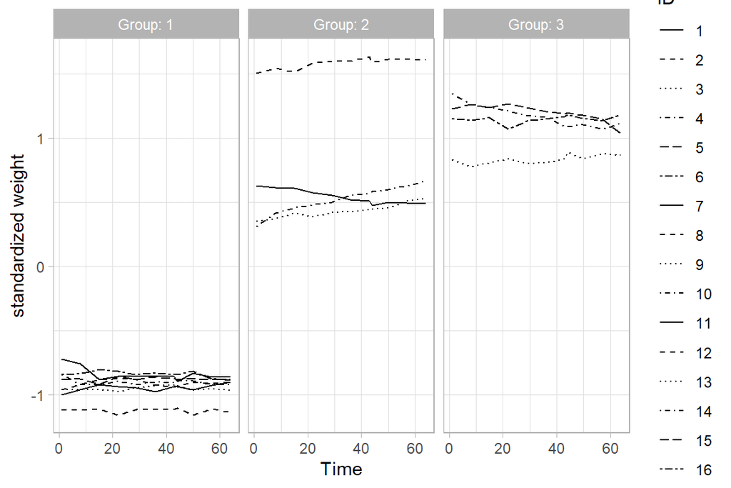

```r
# Plot again with the standardized Weight
library(ggplot2)
ggplot(RATS, aes(x = Time, y = stdweight, linetype = ID)) +
  geom_line() +
  scale_linetype_manual(values = rep(1:10, times=4)) +
  facet_grid(. ~ Group, labeller = label_both) +
  scale_y_continuous(name = "standardized weight")
```

### Mean profiles

```r
# Number of subjects (per group): group 1 n = 8, group 2 & 3 n = 4
n1 <- 8
n23 <- 4

library(dplyr)
library(tidyr)
library(tidyverse)

# Summary data with mean and standard error of Weight by Group1 and Time
RATSS1 <- RATS %>%
  filter(Group == 1) %>%
  group_by(Group, Time) %>%
  summarise(mean = mean(Weight), se = sd(Weight)/sqrt(n1)) %>%
  ungroup()
# Summary data with mean and standard error of Weight by Group 2&3 and Time
RATSS2 <- RATS %>%
  filter(Group %in% c(2,3)) %>%
  group_by(Group, Time) %>%
  summarise(mean = mean(Weight), se = sd(Weight)/sqrt(n23)) %>%
  ungroup()
# Join summary data together, keep all
RATSS <- full_join(RATSS1, RATSS2)
# Glimpse the data
glimpse(RATSS)
```

```
## Rows: 33
## Columns: 4
## $ Group <fct> 1, 1, 1, 1, 1, 1, 1, 1, 1, 1, 1, 2, 2, 2, 2, 2, 2, 2, 2, 2, 2, 2…
## $ Time  <dbl> 1, 8, 15, 22, 29, 36, 43, 44, 50, 57, 64, 1, 8, 15, 22, 29, 36, …
## $ mean  <dbl> 250.625, 255.000, 254.375, 261.875, 264.625, 265.000, 267.375, 2…
## $ se    <dbl> 5.381640, 4.629100, 4.057346, 4.808614, 3.909409, 4.166190, 3.87…
```

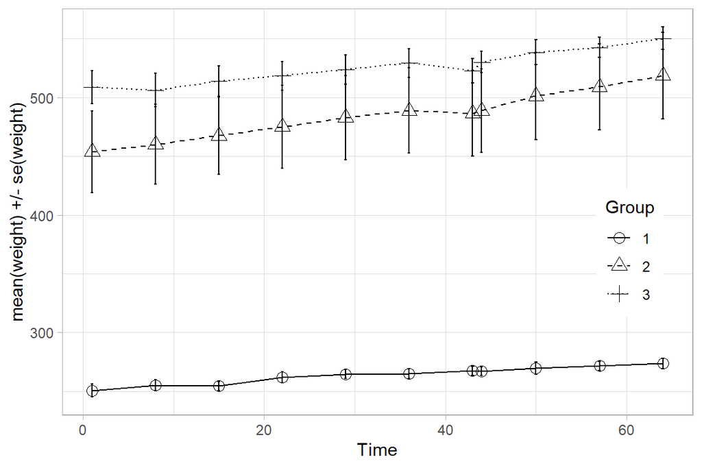

```r
# Plot the mean profiles
library(ggplot2)
ggplot(RATSS, aes(x = Time, y = mean, linetype = Group, shape = Group)) +
  geom_line() +
  scale_linetype_manual(values = c(1,2,3)) +
  geom_point(size=3) +
  scale_shape_manual(values = c(1,2,3)) +
  geom_errorbar(aes(ymin=mean-se, ymax=mean+se, linetype="1"), width=0.3) +
  theme(legend.position = c(0.9,0.4)) +
  scale_y_continuous(name = "mean(weight) +/- se(weight)")
```

The plot of mean profiles clearly show the distinct group 1 which has smaller variability throughout the study. I assumed that it is the control group. As expected based on the previous plot, group 2 shows the highest variability. To note, group 2 and 3 had only 4 rats so the differences between animals in a group can more easily pop up. All groups show the similar trend of increasing mean weight during the study.

### Checking outliers

```r
library(dplyr)
library(tidyr)
# Create a summary data by treatment group and subject (ID) with mean as the summary variable (ignoring baseline measurement Time = 1)
RATSS3 <- RATS %>%
  filter(Time > 1) %>%
  group_by(Group, ID) %>%
  summarise(mean=mean(Weight)) %>%
  ungroup()
# Glimpse the data
glimpse(RATSS3)
```

```
## Rows: 16
## Columns: 3
## $ Group <fct> 1, 1, 1, 1, 1, 1, 1, 1, 2, 2, 2, 2, 3, 3, 3, 3
## $ ID    <fct> 1, 2, 3, 4, 5, 6, 7, 8, 9, 10, 11, 12, 13, 14, 15, 16
## $ mean  <dbl> 263.2, 238.9, 261.7, 267.2, 270.9, 276.2, 274.6, 267.5, 443.9, 4…
```

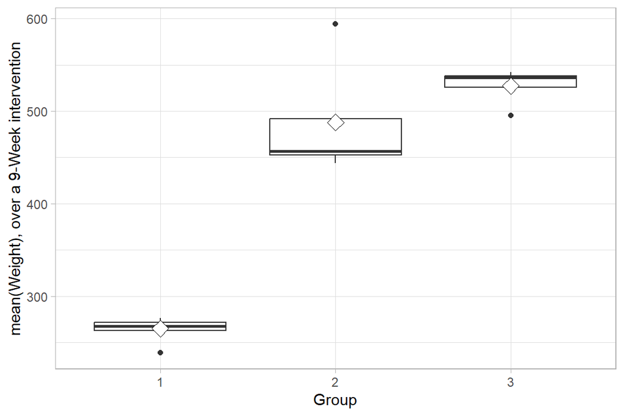

```r
# Draw a boxplot of the mean versus treatment group
library(ggplot2)
ggplot(RATSS3, aes(x = Group, y = mean)) +
  geom_boxplot() +
  stat_summary(fun = "mean", geom = "point", shape=23, size=4, fill = "white") +
  scale_y_continuous(name = "mean(Weight), over a 9-Week intervention")
```

There seems to be outliers in each groups. Let’s filter these out.

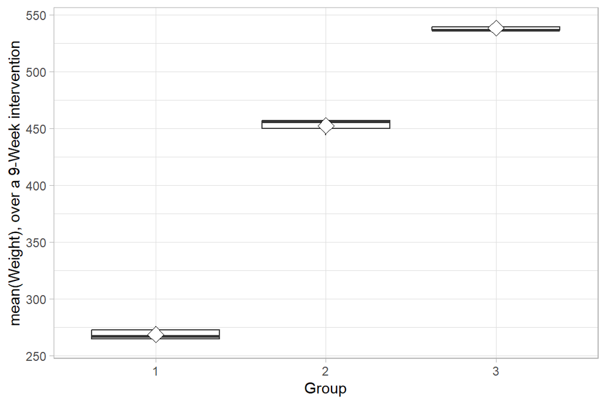

```r
# filtering outliers
RATSS4 <- RATSS3 %>%
  filter((Group == 1 & mean > 250) | (Group == 2 & mean < 550) | (Group == 3 & mean >500) )

# Draw a boxplot of the mean versus treatment group
library(ggplot2)
ggplot(RATSS4, aes(x = Group, y = mean)) +
  geom_boxplot() +
  stat_summary(fun = "mean", geom = "point", shape=23, size=4, fill = "white") +
  scale_y_continuous(name = "mean(Weight), over a 9-Week intervention")
```

This is maybe not the best visualization for this as the scale is large compared to the weight differences in each group. But here you can see again the differences in mean weights between the groups.

### Group differences using ANOVA

Although we have now seen the graphics of the individual and group level data indicating the differences between the groups we still need some statistical test to confirm these findings. As we now have three groups, we can use ANOVA - Analysis of variance (t-test would be fine for two groups). Let’s check how the results looks like when a) including all 16 animals or b) without 3 outliers.

```r
# a) One-way ANOVA to compare group means.
OW_all <- aov(Weight ~ Group, data = RATS) # Weight as an independent variable and group explanatory variable
summary(OW_all)
```

```
##              Df  Sum Sq Mean Sq F value Pr(>F)
## Group         2 2604050 1302025   998.2 <2e-16 ***
## Residuals   173  225662    1304
## ---
## Signif. codes:  0 '***' 0.001 '**' 0.01 '*' 0.05 '.' 0.1 ' ' 1
```

```r
# b) the same using data without expected outliers (ID= 2, 12, and 13)
RATS13 <- RATS %>%
  filter(ID %in% c(1,3:11,14:16))

OW_13rats <- aov(Weight ~ Group, data = RATS13)

summary(OW_13rats)
```

```
##              Df  Sum Sq Mean Sq F value Pr(>F)
## Group         2 1935537  967769    4956 <2e-16 ***
## Residuals   140   27339     195
## ---
## Signif. codes:  0 '***' 0.001 '**' 0.01 '*' 0.05 '.' 0.1 ' ' 1
```

We can see that there are indeed statistically significant differences between the groups. :) And it doesn’t really matter that much which data set to use here.

As stated in the Exercise Set 6: *Baseline measurements of the outcome variable in a longitudinal study are often correlated with the chosen summary measure and using such measures in the analysis can often lead to substantial gains in precision when used appropriately as a covariate in an analysis of covariance.*

Let’s see if this is the case also in the RATS data.

### The effect of baseline on the summary measure in a longitudinal study

```r
library(dplyr)
library(tidyr)

# a) Linear regression using all animals, summary data saved in RATSS3
# read the original wide format data to easily get the baseline data
rats <- read_csv("data/rats.csv")
# Add the baseline from the original data as a new variable to the summary data
RATSS_lm <- RATSS3 %>%
  mutate(baseline = rats$WD1)

# Fit the linear model with the mean as the response
fit1 <- lm(mean ~ baseline + Group, data = RATSS_lm)

# calculate confidence intervals
CI1 <- confint(fit1)
print(CI1)
```

```
##                   2.5 %    97.5 %
## (Intercept) -14.5011937 80.828690
## baseline      0.7383656  1.111899
## Group2       -6.1544447 75.869498
## Group3      -26.9892106 74.339724
```

```r
# Compute the analysis of variance table for the fitted model with anova()
anova(fit1)
```

|  | Df | Sum Sq | Mean Sq | F value | Pr(>F) |
| --- | --- | --- | --- | --- | --- |
| baseline | 1 | 253625.4006 | 253625.4006 | 1859.820128 | 0.0000000 |
| Group | 2 | 878.7458 | 439.3729 | 3.221896 | 0.0758554 |
| Residuals | 12 | 1636.4512 | 136.3709 | NA | NA |

```r
# b) Linear regression using 13 animals (without outlier)

# removing the outliers
RATSS_lm2 <- RATSS_lm %>%
  filter((Group == 1 & mean > 250) | (Group == 2 & mean < 550) | (Group == 3 & mean >500) )

# Fit the linear model with the mean as the response
fit2 <- lm(mean ~ baseline + Group, data = RATSS_lm2)

# calculate confidence intervals
CI2 <- confint(fit2)
print(CI2)
```

```
##                    2.5 %      97.5 %
## (Intercept) 157.26305236 285.3556559
## baseline     -0.06468227   0.4378671
## Group2      110.31713395 195.1265186
## Group3      151.95547978 287.2810458
```

```r
# Compute the analysis of variance table for the fitted model with anova()
anova(fit2)
```

|  | Df | Sum Sq | Mean Sq | F value | Pr(>F) |
| --- | --- | --- | --- | --- | --- |
| baseline | 1 | 174925.9209 | 174925.92094 | 6630.94065 | 0.00e+00 |
| Group | 2 | 2065.4044 | 1032.70222 | 39.14678 | 3.63e-05 |
| Residuals | 9 | 237.4223 | 26.38026 | NA | NA |

```r
# showing model summaries for both models
library(modelsummary)
fits <- list(
  "fit1" <- lm(mean ~ baseline + Group, data = RATSS_lm),
  "fit2" <- lm(mean ~ baseline + Group, data = RATSS_lm2))

modelsummary(fits, output = "html", statistic = c("conf.int", "p = {p.value}"))
```

|  | (1) | (2) |
| --- | --- | --- |
| (Intercept) | 33.164 | 221.309 |
|  | [−14.501, 80.829] | [157.263, 285.356] |
|  | p = 0.155 | p = <0.001 |
| baseline | 0.925 | 0.187 |
|  | [0.738, 1.112] | [−0.065, 0.438] |
|  | p = <0.001 | p = 0.127 |
| Group2 | 34.858 | 152.722 |
|  | [−6.154, 75.869] | [110.317, 195.127] |
|  | p = 0.089 | p = <0.001 |
| Group3 | 23.675 | 219.618 |
|  | [−26.989, 74.340] | [151.955, 287.281] |
|  | p = 0.329 | p = <0.001 |
| Num.Obs. | 16 | 13 |
| R2 | 0.994 | 0.999 |
| R2 Adj. | 0.992 | 0.998 |
| AIC | 129.4 | 84.7 |
| BIC | 133.3 | 87.5 |
| Log.Lik. | −59.725 | −37.328 |
| RMSE | 10.11 | 4.27 |

The results show that the baseline weight is significantly correlated with the mean weight. In the model 1 using all animals it is the ONE significant variable explaining the variance seen in mean weight of rats. In the model 2 using data without group-based outliers, treatment groups but not the baseline are significantly correlated to the mean weights. Both models have R2 (Adj.) close to 1 meaning the the model almost perfectly fit the data. Thus, the main message here is that the baseline weight is definitely affecting the mean weight and this should be taken into account in analysis!

## PART 2: *GPRS* and Linear Mixed Effects Models

*This second part will focus to the BPRS data, in which 40 male subjects were randomly assigned to one of two treatment groups and each subject was rated on the brief psychiatric rating scale (BPRS) measured before treatment (week 0) and then at weekly intervals for eight weeks. The BPRS assesses the level of 18 symptom constructs such as hostility, suspiciousness, hallucinations and grandiosity; each of these is rated from one (not present) to seven (extremely severe). The scale is used to evaluate patients suspected of having schizophrenia.*

```r
# Read the data
library(readr)
BPRSL <- read_csv("data/BPRS_tidy.csv")
library(tidyverse)
#glimpse(BPRSL)

#change treatment and subject to factors
BPRSL <- BPRSL %>%
  mutate(treatment = factor(treatment),
         subject = factor(subject))

glimpse(BPRSL)
```

```
## Rows: 360
## Columns: 5
## $ treatment <fct> 1, 1, 1, 1, 1, 1, 1, 1, 1, 1, 1, 1, 1, 1, 1, 1, 1, 1, 1, 1, …
## $ subject   <fct> 1, 2, 3, 4, 5, 6, 7, 8, 9, 10, 11, 12, 13, 14, 15, 16, 17, 1…
## $ weeks     <chr> "week0", "week0", "week0", "week0", "week0", "week0", "week0…
## $ BPRS      <dbl> 42, 58, 54, 55, 72, 48, 71, 30, 41, 57, 30, 55, 36, 38, 66, …
## $ week      <dbl> 0, 0, 0, 0, 0, 0, 0, 0, 0, 0, 0, 0, 0, 0, 0, 0, 0, 0, 0, 0, …
```

There are 360 observations and 5 columns. “Weeks” columns is from the original wide form data which was used to create the “week” variable to indicate the time point (week) during the study as a numerical value. Treatment and subject are factored for plotting and analysis.